# Practice for Exam on Nov 24

Simplify the radical:

$$\sqrt{75}$$

$2\sqrt{2}$$2\sqrt{3}$$2\sqrt{5}$$2\sqrt{7}$$2\sqrt{11}$$3\sqrt{2}$$3\sqrt{3}$$3\sqrt{5}$$3\sqrt{7}$$3\sqrt{11}$$5\sqrt{2}$$5\sqrt{3}$$5\sqrt{5}$$5\sqrt{7}$$5\sqrt{11}$$7\sqrt{2}$$7\sqrt{3}$$7\sqrt{5}$$7\sqrt{7}$$7\sqrt{11}$$11\sqrt{2}$$11\sqrt{3}$$11\sqrt{5}$$11\sqrt{7}$$11\sqrt{11}$

$$\sqrt{75}$$

Find the [prime factorization](https://en.wikipedia.org/wiki/Fundamental_theorem_of_arithmetic) of 75. You can do this with a [factor tree](https://www.khanacademy.org/math/pre-algebra/pre-algebra-factors-multiples/pre-algebra-prime-factorization-prealg/v/prime-factorization). You should find that $75=3^{1}\cdot5^{2}$.

$$\sqrt{3^{1}\cdot5^{2}}$$

[Simplify the square root](https://www.khanacademy.org/math/algebra/x2f8bb11595b61c86:rational-exponents-radicals/x2f8bb11595b61c86:simplifying-square-roots/v/simplifying-square-roots-1).

$$5 \sqrt{3}$$

Simplify the radical:

$$\sqrt{8}$$

$2\sqrt{2}$$2\sqrt{3}$$2\sqrt{5}$$2\sqrt{7}$$2\sqrt{11}$$3\sqrt{2}$$3\sqrt{3}$$3\sqrt{5}$$3\sqrt{7}$$3\sqrt{11}$$5\sqrt{2}$$5\sqrt{3}$$5\sqrt{5}$$5\sqrt{7}$$5\sqrt{11}$$7\sqrt{2}$$7\sqrt{3}$$7\sqrt{5}$$7\sqrt{7}$$7\sqrt{11}$$11\sqrt{2}$$11\sqrt{3}$$11\sqrt{5}$$11\sqrt{7}$$11\sqrt{11}$

$$\sqrt{8}$$

Find the [prime factorization](https://en.wikipedia.org/wiki/Fundamental_theorem_of_arithmetic) of 8. You can do this with a [factor tree](https://www.khanacademy.org/math/pre-algebra/pre-algebra-factors-multiples/pre-algebra-prime-factorization-prealg/v/prime-factorization). You should find that $8=2^{3}$.

$$\sqrt{2^{3}}$$

[Simplify the square root](https://www.khanacademy.org/math/algebra/x2f8bb11595b61c86:rational-exponents-radicals/x2f8bb11595b61c86:simplifying-square-roots/v/simplifying-square-roots-1).

$$2 \sqrt{2}$$

Simplify the radical:

$$\sqrt{45}$$

$2\sqrt{2}$$2\sqrt{3}$$2\sqrt{5}$$2\sqrt{7}$$2\sqrt{11}$$3\sqrt{2}$$3\sqrt{3}$$3\sqrt{5}$$3\sqrt{7}$$3\sqrt{11}$$5\sqrt{2}$$5\sqrt{3}$$5\sqrt{5}$$5\sqrt{7}$$5\sqrt{11}$$7\sqrt{2}$$7\sqrt{3}$$7\sqrt{5}$$7\sqrt{7}$$7\sqrt{11}$$11\sqrt{2}$$11\sqrt{3}$$11\sqrt{5}$$11\sqrt{7}$$11\sqrt{11}$

$$\sqrt{45}$$

Find the [prime factorization](https://en.wikipedia.org/wiki/Fundamental_theorem_of_arithmetic) of 45. You can do this with a [factor tree](https://www.khanacademy.org/math/pre-algebra/pre-algebra-factors-multiples/pre-algebra-prime-factorization-prealg/v/prime-factorization). You should find that $45=3^{2}\cdot5^{1}$.

$$\sqrt{3^{2}\cdot5^{1}}$$

[Simplify the square root](https://www.khanacademy.org/math/algebra/x2f8bb11595b61c86:rational-exponents-radicals/x2f8bb11595b61c86:simplifying-square-roots/v/simplifying-square-roots-1).

$$3 \sqrt{5}$$

Simplify the radical:

$$\sqrt{50}$$

$2\sqrt{2}$$2\sqrt{3}$$2\sqrt{5}$$2\sqrt{7}$$2\sqrt{11}$$3\sqrt{2}$$3\sqrt{3}$$3\sqrt{5}$$3\sqrt{7}$$3\sqrt{11}$$5\sqrt{2}$$5\sqrt{3}$$5\sqrt{5}$$5\sqrt{7}$$5\sqrt{11}$$7\sqrt{2}$$7\sqrt{3}$$7\sqrt{5}$$7\sqrt{7}$$7\sqrt{11}$$11\sqrt{2}$$11\sqrt{3}$$11\sqrt{5}$$11\sqrt{7}$$11\sqrt{11}$

$$\sqrt{50}$$

Find the [prime factorization](https://en.wikipedia.org/wiki/Fundamental_theorem_of_arithmetic) of 50. You can do this with a [factor tree](https://www.khanacademy.org/math/pre-algebra/pre-algebra-factors-multiples/pre-algebra-prime-factorization-prealg/v/prime-factorization). You should find that $50=2^{1}\cdot5^{2}$.

$$\sqrt{2^{1}\cdot5^{2}}$$

[Simplify the square root](https://www.khanacademy.org/math/algebra/x2f8bb11595b61c86:rational-exponents-radicals/x2f8bb11595b61c86:simplifying-square-roots/v/simplifying-square-roots-1).

$$5 \sqrt{2}$$

Simplify the radical:

$$\sqrt{12}$$

$2\sqrt{2}$$2\sqrt{3}$$2\sqrt{5}$$2\sqrt{7}$$2\sqrt{11}$$3\sqrt{2}$$3\sqrt{3}$$3\sqrt{5}$$3\sqrt{7}$$3\sqrt{11}$$5\sqrt{2}$$5\sqrt{3}$$5\sqrt{5}$$5\sqrt{7}$$5\sqrt{11}$$7\sqrt{2}$$7\sqrt{3}$$7\sqrt{5}$$7\sqrt{7}$$7\sqrt{11}$$11\sqrt{2}$$11\sqrt{3}$$11\sqrt{5}$$11\sqrt{7}$$11\sqrt{11}$

$$\sqrt{12}$$

Find the [prime factorization](https://en.wikipedia.org/wiki/Fundamental_theorem_of_arithmetic) of 12. You can do this with a [factor tree](https://www.khanacademy.org/math/pre-algebra/pre-algebra-factors-multiples/pre-algebra-prime-factorization-prealg/v/prime-factorization). You should find that $12=2^{2}\cdot3^{1}$.

$$\sqrt{2^{2}\cdot3^{1}}$$

[Simplify the square root](https://www.khanacademy.org/math/algebra/x2f8bb11595b61c86:rational-exponents-radicals/x2f8bb11595b61c86:simplifying-square-roots/v/simplifying-square-roots-1).

$$2 \sqrt{3}$$

Simplify the radical:

$$\sqrt{99}$$

$2\sqrt{2}$$2\sqrt{3}$$2\sqrt{5}$$2\sqrt{7}$$2\sqrt{11}$$3\sqrt{2}$$3\sqrt{3}$$3\sqrt{5}$$3\sqrt{7}$$3\sqrt{11}$$5\sqrt{2}$$5\sqrt{3}$$5\sqrt{5}$$5\sqrt{7}$$5\sqrt{11}$$7\sqrt{2}$$7\sqrt{3}$$7\sqrt{5}$$7\sqrt{7}$$7\sqrt{11}$$11\sqrt{2}$$11\sqrt{3}$$11\sqrt{5}$$11\sqrt{7}$$11\sqrt{11}$

$$\sqrt{99}$$

Find the [prime factorization](https://en.wikipedia.org/wiki/Fundamental_theorem_of_arithmetic) of 99. You can do this with a [factor tree](https://www.khanacademy.org/math/pre-algebra/pre-algebra-factors-multiples/pre-algebra-prime-factorization-prealg/v/prime-factorization). You should find that $99=3^{2}\cdot11^{1}$.

$$\sqrt{3^{2}\cdot11^{1}}$$

[Simplify the square root](https://www.khanacademy.org/math/algebra/x2f8bb11595b61c86:rational-exponents-radicals/x2f8bb11595b61c86:simplifying-square-roots/v/simplifying-square-roots-1).

$$3 \sqrt{11}$$

Simplify the radical:

$$\sqrt{28}$$

$2\sqrt{2}$$2\sqrt{3}$$2\sqrt{5}$$2\sqrt{7}$$2\sqrt{11}$$3\sqrt{2}$$3\sqrt{3}$$3\sqrt{5}$$3\sqrt{7}$$3\sqrt{11}$$5\sqrt{2}$$5\sqrt{3}$$5\sqrt{5}$$5\sqrt{7}$$5\sqrt{11}$$7\sqrt{2}$$7\sqrt{3}$$7\sqrt{5}$$7\sqrt{7}$$7\sqrt{11}$$11\sqrt{2}$$11\sqrt{3}$$11\sqrt{5}$$11\sqrt{7}$$11\sqrt{11}$

$$\sqrt{28}$$

Find the [prime factorization](https://en.wikipedia.org/wiki/Fundamental_theorem_of_arithmetic) of 28. You can do this with a [factor tree](https://www.khanacademy.org/math/pre-algebra/pre-algebra-factors-multiples/pre-algebra-prime-factorization-prealg/v/prime-factorization). You should find that $28=2^{2}\cdot7^{1}$.

$$\sqrt{2^{2}\cdot7^{1}}$$

[Simplify the square root](https://www.khanacademy.org/math/algebra/x2f8bb11595b61c86:rational-exponents-radicals/x2f8bb11595b61c86:simplifying-square-roots/v/simplifying-square-roots-1).

$$2 \sqrt{7}$$

Simplify the radical:

$$\sqrt{63}$$

$2\sqrt{2}$$2\sqrt{3}$$2\sqrt{5}$$2\sqrt{7}$$2\sqrt{11}$$3\sqrt{2}$$3\sqrt{3}$$3\sqrt{5}$$3\sqrt{7}$$3\sqrt{11}$$5\sqrt{2}$$5\sqrt{3}$$5\sqrt{5}$$5\sqrt{7}$$5\sqrt{11}$$7\sqrt{2}$$7\sqrt{3}$$7\sqrt{5}$$7\sqrt{7}$$7\sqrt{11}$$11\sqrt{2}$$11\sqrt{3}$$11\sqrt{5}$$11\sqrt{7}$$11\sqrt{11}$

$$\sqrt{63}$$

Find the [prime factorization](https://en.wikipedia.org/wiki/Fundamental_theorem_of_arithmetic) of 63. You can do this with a [factor tree](https://www.khanacademy.org/math/pre-algebra/pre-algebra-factors-multiples/pre-algebra-prime-factorization-prealg/v/prime-factorization). You should find that $63=3^{2}\cdot7^{1}$.

$$\sqrt{3^{2}\cdot7^{1}}$$

[Simplify the square root](https://www.khanacademy.org/math/algebra/x2f8bb11595b61c86:rational-exponents-radicals/x2f8bb11595b61c86:simplifying-square-roots/v/simplifying-square-roots-1).

$$3 \sqrt{7}$$

Simplify the radical:

$$\sqrt{50}$$

$2\sqrt{2}$$2\sqrt{3}$$2\sqrt{5}$$2\sqrt{7}$$2\sqrt{11}$$3\sqrt{2}$$3\sqrt{3}$$3\sqrt{5}$$3\sqrt{7}$$3\sqrt{11}$$5\sqrt{2}$$5\sqrt{3}$$5\sqrt{5}$$5\sqrt{7}$$5\sqrt{11}$$7\sqrt{2}$$7\sqrt{3}$$7\sqrt{5}$$7\sqrt{7}$$7\sqrt{11}$$11\sqrt{2}$$11\sqrt{3}$$11\sqrt{5}$$11\sqrt{7}$$11\sqrt{11}$

$$\sqrt{50}$$

Find the [prime factorization](https://en.wikipedia.org/wiki/Fundamental_theorem_of_arithmetic) of 50. You can do this with a [factor tree](https://www.khanacademy.org/math/pre-algebra/pre-algebra-factors-multiples/pre-algebra-prime-factorization-prealg/v/prime-factorization). You should find that $50=2^{1}\cdot5^{2}$.

$$\sqrt{2^{1}\cdot5^{2}}$$

[Simplify the square root](https://www.khanacademy.org/math/algebra/x2f8bb11595b61c86:rational-exponents-radicals/x2f8bb11595b61c86:simplifying-square-roots/v/simplifying-square-roots-1).

$$5 \sqrt{2}$$

Simplify the radical:

$$\sqrt{44}$$

$2\sqrt{2}$$2\sqrt{3}$$2\sqrt{5}$$2\sqrt{7}$$2\sqrt{11}$$3\sqrt{2}$$3\sqrt{3}$$3\sqrt{5}$$3\sqrt{7}$$3\sqrt{11}$$5\sqrt{2}$$5\sqrt{3}$$5\sqrt{5}$$5\sqrt{7}$$5\sqrt{11}$$7\sqrt{2}$$7\sqrt{3}$$7\sqrt{5}$$7\sqrt{7}$$7\sqrt{11}$$11\sqrt{2}$$11\sqrt{3}$$11\sqrt{5}$$11\sqrt{7}$$11\sqrt{11}$

$$\sqrt{44}$$

Find the [prime factorization](https://en.wikipedia.org/wiki/Fundamental_theorem_of_arithmetic) of 44. You can do this with a [factor tree](https://www.khanacademy.org/math/pre-algebra/pre-algebra-factors-multiples/pre-algebra-prime-factorization-prealg/v/prime-factorization). You should find that $44=2^{2}\cdot11^{1}$.

$$\sqrt{2^{2}\cdot11^{1}}$$

[Simplify the square root](https://www.khanacademy.org/math/algebra/x2f8bb11595b61c86:rational-exponents-radicals/x2f8bb11595b61c86:simplifying-square-roots/v/simplifying-square-roots-1).

$$2 \sqrt{11}$$

Simplify the radical:

$$\sqrt{44}$$

$2\sqrt{2}$$2\sqrt{3}$$2\sqrt{5}$$2\sqrt{7}$$2\sqrt{11}$$3\sqrt{2}$$3\sqrt{3}$$3\sqrt{5}$$3\sqrt{7}$$3\sqrt{11}$$5\sqrt{2}$$5\sqrt{3}$$5\sqrt{5}$$5\sqrt{7}$$5\sqrt{11}$$7\sqrt{2}$$7\sqrt{3}$$7\sqrt{5}$$7\sqrt{7}$$7\sqrt{11}$$11\sqrt{2}$$11\sqrt{3}$$11\sqrt{5}$$11\sqrt{7}$$11\sqrt{11}$

$$\sqrt{44}$$

Find the [prime factorization](https://en.wikipedia.org/wiki/Fundamental_theorem_of_arithmetic) of 44. You can do this with a [factor tree](https://www.khanacademy.org/math/pre-algebra/pre-algebra-factors-multiples/pre-algebra-prime-factorization-prealg/v/prime-factorization). You should find that $44=2^{2}\cdot11^{1}$.

$$\sqrt{2^{2}\cdot11^{1}}$$

[Simplify the square root](https://www.khanacademy.org/math/algebra/x2f8bb11595b61c86:rational-exponents-radicals/x2f8bb11595b61c86:simplifying-square-roots/v/simplifying-square-roots-1).

$$2 \sqrt{11}$$

Simplify the radical:

$$\sqrt{45}$$

$2\sqrt{2}$$2\sqrt{3}$$2\sqrt{5}$$2\sqrt{7}$$2\sqrt{11}$$3\sqrt{2}$$3\sqrt{3}$$3\sqrt{5}$$3\sqrt{7}$$3\sqrt{11}$$5\sqrt{2}$$5\sqrt{3}$$5\sqrt{5}$$5\sqrt{7}$$5\sqrt{11}$$7\sqrt{2}$$7\sqrt{3}$$7\sqrt{5}$$7\sqrt{7}$$7\sqrt{11}$$11\sqrt{2}$$11\sqrt{3}$$11\sqrt{5}$$11\sqrt{7}$$11\sqrt{11}$

$$\sqrt{45}$$

Find the [prime factorization](https://en.wikipedia.org/wiki/Fundamental_theorem_of_arithmetic) of 45. You can do this with a [factor tree](https://www.khanacademy.org/math/pre-algebra/pre-algebra-factors-multiples/pre-algebra-prime-factorization-prealg/v/prime-factorization). You should find that $45=3^{2}\cdot5^{1}$.

$$\sqrt{3^{2}\cdot5^{1}}$$

[Simplify the square root](https://www.khanacademy.org/math/algebra/x2f8bb11595b61c86:rational-exponents-radicals/x2f8bb11595b61c86:simplifying-square-roots/v/simplifying-square-roots-1).

$$3 \sqrt{5}$$

Simplify the radical:

$$\sqrt{44}$$

$2\sqrt{2}$$2\sqrt{3}$$2\sqrt{5}$$2\sqrt{7}$$2\sqrt{11}$$3\sqrt{2}$$3\sqrt{3}$$3\sqrt{5}$$3\sqrt{7}$$3\sqrt{11}$$5\sqrt{2}$$5\sqrt{3}$$5\sqrt{5}$$5\sqrt{7}$$5\sqrt{11}$$7\sqrt{2}$$7\sqrt{3}$$7\sqrt{5}$$7\sqrt{7}$$7\sqrt{11}$$11\sqrt{2}$$11\sqrt{3}$$11\sqrt{5}$$11\sqrt{7}$$11\sqrt{11}$

$$\sqrt{44}$$

Find the [prime factorization](https://en.wikipedia.org/wiki/Fundamental_theorem_of_arithmetic) of 44. You can do this with a [factor tree](https://www.khanacademy.org/math/pre-algebra/pre-algebra-factors-multiples/pre-algebra-prime-factorization-prealg/v/prime-factorization). You should find that $44=2^{2}\cdot11^{1}$.

$$\sqrt{2^{2}\cdot11^{1}}$$

[Simplify the square root](https://www.khanacademy.org/math/algebra/x2f8bb11595b61c86:rational-exponents-radicals/x2f8bb11595b61c86:simplifying-square-roots/v/simplifying-square-roots-1).

$$2 \sqrt{11}$$

Simplify the radical:

$$\sqrt{8}$$

$2\sqrt{2}$$2\sqrt{3}$$2\sqrt{5}$$2\sqrt{7}$$2\sqrt{11}$$3\sqrt{2}$$3\sqrt{3}$$3\sqrt{5}$$3\sqrt{7}$$3\sqrt{11}$$5\sqrt{2}$$5\sqrt{3}$$5\sqrt{5}$$5\sqrt{7}$$5\sqrt{11}$$7\sqrt{2}$$7\sqrt{3}$$7\sqrt{5}$$7\sqrt{7}$$7\sqrt{11}$$11\sqrt{2}$$11\sqrt{3}$$11\sqrt{5}$$11\sqrt{7}$$11\sqrt{11}$

$$\sqrt{8}$$

Find the [prime factorization](https://en.wikipedia.org/wiki/Fundamental_theorem_of_arithmetic) of 8. You can do this with a [factor tree](https://www.khanacademy.org/math/pre-algebra/pre-algebra-factors-multiples/pre-algebra-prime-factorization-prealg/v/prime-factorization). You should find that $8=2^{3}$.

$$\sqrt{2^{3}}$$

[Simplify the square root](https://www.khanacademy.org/math/algebra/x2f8bb11595b61c86:rational-exponents-radicals/x2f8bb11595b61c86:simplifying-square-roots/v/simplifying-square-roots-1).

$$2 \sqrt{2}$$

Simplify the radical:

$$\sqrt{99}$$

$2\sqrt{2}$$2\sqrt{3}$$2\sqrt{5}$$2\sqrt{7}$$2\sqrt{11}$$3\sqrt{2}$$3\sqrt{3}$$3\sqrt{5}$$3\sqrt{7}$$3\sqrt{11}$$5\sqrt{2}$$5\sqrt{3}$$5\sqrt{5}$$5\sqrt{7}$$5\sqrt{11}$$7\sqrt{2}$$7\sqrt{3}$$7\sqrt{5}$$7\sqrt{7}$$7\sqrt{11}$$11\sqrt{2}$$11\sqrt{3}$$11\sqrt{5}$$11\sqrt{7}$$11\sqrt{11}$

$$\sqrt{99}$$

Find the [prime factorization](https://en.wikipedia.org/wiki/Fundamental_theorem_of_arithmetic) of 99. You can do this with a [factor tree](https://www.khanacademy.org/math/pre-algebra/pre-algebra-factors-multiples/pre-algebra-prime-factorization-prealg/v/prime-factorization). You should find that $99=3^{2}\cdot11^{1}$.

$$\sqrt{3^{2}\cdot11^{1}}$$

[Simplify the square root](https://www.khanacademy.org/math/algebra/x2f8bb11595b61c86:rational-exponents-radicals/x2f8bb11595b61c86:simplifying-square-roots/v/simplifying-square-roots-1).

$$3 \sqrt{11}$$

Simplify the radical:

$$\sqrt{27}$$

$2\sqrt{2}$$2\sqrt{3}$$2\sqrt{5}$$2\sqrt{7}$$2\sqrt{11}$$3\sqrt{2}$$3\sqrt{3}$$3\sqrt{5}$$3\sqrt{7}$$3\sqrt{11}$$5\sqrt{2}$$5\sqrt{3}$$5\sqrt{5}$$5\sqrt{7}$$5\sqrt{11}$$7\sqrt{2}$$7\sqrt{3}$$7\sqrt{5}$$7\sqrt{7}$$7\sqrt{11}$$11\sqrt{2}$$11\sqrt{3}$$11\sqrt{5}$$11\sqrt{7}$$11\sqrt{11}$

$$\sqrt{27}$$

Find the [prime factorization](https://en.wikipedia.org/wiki/Fundamental_theorem_of_arithmetic) of 27. You can do this with a [factor tree](https://www.khanacademy.org/math/pre-algebra/pre-algebra-factors-multiples/pre-algebra-prime-factorization-prealg/v/prime-factorization). You should find that $27=3^{3}$.

$$\sqrt{3^{3}}$$

[Simplify the square root](https://www.khanacademy.org/math/algebra/x2f8bb11595b61c86:rational-exponents-radicals/x2f8bb11595b61c86:simplifying-square-roots/v/simplifying-square-roots-1).

$$3 \sqrt{3}$$

Simplify the radical:

$$\sqrt{20}$$

$2\sqrt{2}$$2\sqrt{3}$$2\sqrt{5}$$2\sqrt{7}$$2\sqrt{11}$$3\sqrt{2}$$3\sqrt{3}$$3\sqrt{5}$$3\sqrt{7}$$3\sqrt{11}$$5\sqrt{2}$$5\sqrt{3}$$5\sqrt{5}$$5\sqrt{7}$$5\sqrt{11}$$7\sqrt{2}$$7\sqrt{3}$$7\sqrt{5}$$7\sqrt{7}$$7\sqrt{11}$$11\sqrt{2}$$11\sqrt{3}$$11\sqrt{5}$$11\sqrt{7}$$11\sqrt{11}$

$$\sqrt{20}$$

Find the [prime factorization](https://en.wikipedia.org/wiki/Fundamental_theorem_of_arithmetic) of 20. You can do this with a [factor tree](https://www.khanacademy.org/math/pre-algebra/pre-algebra-factors-multiples/pre-algebra-prime-factorization-prealg/v/prime-factorization). You should find that $20=2^{2}\cdot5^{1}$.

$$\sqrt{2^{2}\cdot5^{1}}$$

[Simplify the square root](https://www.khanacademy.org/math/algebra/x2f8bb11595b61c86:rational-exponents-radicals/x2f8bb11595b61c86:simplifying-square-roots/v/simplifying-square-roots-1).

$$2 \sqrt{5}$$

Simplify the radical:

$$\sqrt{18}$$

$2\sqrt{2}$$2\sqrt{3}$$2\sqrt{5}$$2\sqrt{7}$$2\sqrt{11}$$3\sqrt{2}$$3\sqrt{3}$$3\sqrt{5}$$3\sqrt{7}$$3\sqrt{11}$$5\sqrt{2}$$5\sqrt{3}$$5\sqrt{5}$$5\sqrt{7}$$5\sqrt{11}$$7\sqrt{2}$$7\sqrt{3}$$7\sqrt{5}$$7\sqrt{7}$$7\sqrt{11}$$11\sqrt{2}$$11\sqrt{3}$$11\sqrt{5}$$11\sqrt{7}$$11\sqrt{11}$

$$\sqrt{18}$$

Find the [prime factorization](https://en.wikipedia.org/wiki/Fundamental_theorem_of_arithmetic) of 18. You can do this with a [factor tree](https://www.khanacademy.org/math/pre-algebra/pre-algebra-factors-multiples/pre-algebra-prime-factorization-prealg/v/prime-factorization). You should find that $18=2^{1}\cdot3^{2}$.

$$\sqrt{2^{1}\cdot3^{2}}$$

[Simplify the square root](https://www.khanacademy.org/math/algebra/x2f8bb11595b61c86:rational-exponents-radicals/x2f8bb11595b61c86:simplifying-square-roots/v/simplifying-square-roots-1).

$$3 \sqrt{2}$$

Simplify the radical:

$$\sqrt{45}$$

$2\sqrt{2}$$2\sqrt{3}$$2\sqrt{5}$$2\sqrt{7}$$2\sqrt{11}$$3\sqrt{2}$$3\sqrt{3}$$3\sqrt{5}$$3\sqrt{7}$$3\sqrt{11}$$5\sqrt{2}$$5\sqrt{3}$$5\sqrt{5}$$5\sqrt{7}$$5\sqrt{11}$$7\sqrt{2}$$7\sqrt{3}$$7\sqrt{5}$$7\sqrt{7}$$7\sqrt{11}$$11\sqrt{2}$$11\sqrt{3}$$11\sqrt{5}$$11\sqrt{7}$$11\sqrt{11}$

$$\sqrt{45}$$

Find the [prime factorization](https://en.wikipedia.org/wiki/Fundamental_theorem_of_arithmetic) of 45. You can do this with a [factor tree](https://www.khanacademy.org/math/pre-algebra/pre-algebra-factors-multiples/pre-algebra-prime-factorization-prealg/v/prime-factorization). You should find that $45=3^{2}\cdot5^{1}$.

$$\sqrt{3^{2}\cdot5^{1}}$$

[Simplify the square root](https://www.khanacademy.org/math/algebra/x2f8bb11595b61c86:rational-exponents-radicals/x2f8bb11595b61c86:simplifying-square-roots/v/simplifying-square-roots-1).

$$3 \sqrt{5}$$

Simplify the radical:

$$\sqrt{20}$$

$2\sqrt{2}$$2\sqrt{3}$$2\sqrt{5}$$2\sqrt{7}$$2\sqrt{11}$$3\sqrt{2}$$3\sqrt{3}$$3\sqrt{5}$$3\sqrt{7}$$3\sqrt{11}$$5\sqrt{2}$$5\sqrt{3}$$5\sqrt{5}$$5\sqrt{7}$$5\sqrt{11}$$7\sqrt{2}$$7\sqrt{3}$$7\sqrt{5}$$7\sqrt{7}$$7\sqrt{11}$$11\sqrt{2}$$11\sqrt{3}$$11\sqrt{5}$$11\sqrt{7}$$11\sqrt{11}$

$$\sqrt{20}$$

Find the [prime factorization](https://en.wikipedia.org/wiki/Fundamental_theorem_of_arithmetic) of 20. You can do this with a [factor tree](https://www.khanacademy.org/math/pre-algebra/pre-algebra-factors-multiples/pre-algebra-prime-factorization-prealg/v/prime-factorization). You should find that $20=2^{2}\cdot5^{1}$.

$$\sqrt{2^{2}\cdot5^{1}}$$

[Simplify the square root](https://www.khanacademy.org/math/algebra/x2f8bb11595b61c86:rational-exponents-radicals/x2f8bb11595b61c86:simplifying-square-roots/v/simplifying-square-roots-1).

$$2 \sqrt{5}$$

Find all solutions to the equation below:

$$2 (x+{9})^2+16~=~114$$

$x=-20$$x=-19$$x=-18$$x=-17$$x=-16$$x=-15$$x=-14$$x=-13$$x=-12$$x=-11$$x=-10$$x=-9$$x=-8$$x=-7$$x=-6$$x=-5$$x=-4$$x=-3$$x=-2$$x=-1$$x=0$$x=1$$x=2$$x=3$$x=4$$x=5$$x=6$$x=7$$x=8$$x=9$$x=10$$x=11$$x=12$$x=13$$x=14$$x=15$$x=16$$x=17$$x=18$$x=19$$x=20$

$$2 (x+{9})^2+16~=~114$$

First, subtract 16 from both sides.

$$2 (x+{9})^2~=~98$$

Second, divide both sides by 2.

$$(x+{9})^2~=~49$$

Undo the squaring. Remember the plus-minus symbol!

$$x+{9}~=~\pm7$$

Subtract 9 from both sides.

$$x~=~-9\pm7$$

So the two solutions are $x=-2$ and $x=-16$.

Find all solutions to the equation below:

$$\frac{(x-{7})^2}{4}+11~=~15$$

$x=-20$$x=-19$$x=-18$$x=-17$$x=-16$$x=-15$$x=-14$$x=-13$$x=-12$$x=-11$$x=-10$$x=-9$$x=-8$$x=-7$$x=-6$$x=-5$$x=-4$$x=-3$$x=-2$$x=-1$$x=0$$x=1$$x=2$$x=3$$x=4$$x=5$$x=6$$x=7$$x=8$$x=9$$x=10$$x=11$$x=12$$x=13$$x=14$$x=15$$x=16$$x=17$$x=18$$x=19$$x=20$

$$\frac{(x-{7})^2}{4}+11~=~15$$

First, subtract 11 from both sides.

$$\frac{(x-{7})^2}{4}~=~4$$

Second, multiply both sides by 4.

$$(x-{7})^2~=~16$$

Undo the squaring. Remember the plus-minus symbol!

$$x-{7}~=~\pm4$$

Add 7 to both sides.

$$x~=~7\pm4$$

So the two solutions are $x=11$ and $x=3$.

Find all solutions to the equation below:

$$\frac{(x-{10})^2-9}{4}~=~10$$

$x=-20$$x=-19$$x=-18$$x=-17$$x=-16$$x=-15$$x=-14$$x=-13$$x=-12$$x=-11$$x=-10$$x=-9$$x=-8$$x=-7$$x=-6$$x=-5$$x=-4$$x=-3$$x=-2$$x=-1$$x=0$$x=1$$x=2$$x=3$$x=4$$x=5$$x=6$$x=7$$x=8$$x=9$$x=10$$x=11$$x=12$$x=13$$x=14$$x=15$$x=16$$x=17$$x=18$$x=19$$x=20$

$$\frac{(x-{10})^2-9}{4}~=~10$$

First, multiply both sides by 4.

$$(x-{10})^2-9~=~40$$

Second, add 9 to both sides.

$$(x-{10})^2~=~49$$

Undo the squaring. Remember the plus-minus symbol!

$$x-{10}~=~\pm7$$

Add 10 to both sides.

$$x~=~10\pm7$$

So the two solutions are $x=17$ and $x=3$.

Find all solutions to the equation below:

$$\frac{(x+{9})^2-7}{3}~=~3$$

$x=-20$$x=-19$$x=-18$$x=-17$$x=-16$$x=-15$$x=-14$$x=-13$$x=-12$$x=-11$$x=-10$$x=-9$$x=-8$$x=-7$$x=-6$$x=-5$$x=-4$$x=-3$$x=-2$$x=-1$$x=0$$x=1$$x=2$$x=3$$x=4$$x=5$$x=6$$x=7$$x=8$$x=9$$x=10$$x=11$$x=12$$x=13$$x=14$$x=15$$x=16$$x=17$$x=18$$x=19$$x=20$

$$\frac{(x+{9})^2-7}{3}~=~3$$

First, multiply both sides by 3.

$$(x+{9})^2-7~=~9$$

Second, add 7 to both sides.

$$(x+{9})^2~=~16$$

Undo the squaring. Remember the plus-minus symbol!

$$x+{9}~=~\pm4$$

Subtract 9 from both sides.

$$x~=~-9\pm4$$

So the two solutions are $x=-5$ and $x=-13$.

Find all solutions to the equation below:

$$\frac{(x-{6})^2}{16}-18~=~-14$$

$x=-20$$x=-19$$x=-18$$x=-17$$x=-16$$x=-15$$x=-14$$x=-13$$x=-12$$x=-11$$x=-10$$x=-9$$x=-8$$x=-7$$x=-6$$x=-5$$x=-4$$x=-3$$x=-2$$x=-1$$x=0$$x=1$$x=2$$x=3$$x=4$$x=5$$x=6$$x=7$$x=8$$x=9$$x=10$$x=11$$x=12$$x=13$$x=14$$x=15$$x=16$$x=17$$x=18$$x=19$$x=20$

$$\frac{(x-{6})^2}{16}-18~=~-14$$

First, add 18 to both sides.

$$\frac{(x-{6})^2}{16}~=~4$$

Second, multiply both sides by 16.

$$(x-{6})^2~=~64$$

Undo the squaring. Remember the plus-minus symbol!

$$x-{6}~=~\pm8$$

Add 6 to both sides.

$$x~=~6\pm8$$

So the two solutions are $x=14$ and $x=-2$.

Find all solutions to the equation below:

$$\frac{(x+{10})^2}{8}-18~=~-16$$

$x=-20$$x=-19$$x=-18$$x=-17$$x=-16$$x=-15$$x=-14$$x=-13$$x=-12$$x=-11$$x=-10$$x=-9$$x=-8$$x=-7$$x=-6$$x=-5$$x=-4$$x=-3$$x=-2$$x=-1$$x=0$$x=1$$x=2$$x=3$$x=4$$x=5$$x=6$$x=7$$x=8$$x=9$$x=10$$x=11$$x=12$$x=13$$x=14$$x=15$$x=16$$x=17$$x=18$$x=19$$x=20$

$$\frac{(x+{10})^2}{8}-18~=~-16$$

First, add 18 to both sides.

$$\frac{(x+{10})^2}{8}~=~2$$

Second, multiply both sides by 8.

$$(x+{10})^2~=~16$$

Undo the squaring. Remember the plus-minus symbol!

$$x+{10}~=~\pm4$$

Subtract 10 from both sides.

$$x~=~-10\pm4$$

So the two solutions are $x=-6$ and $x=-14$.

Find all solutions to the equation below:

$$3 (x-{7})^2-2~=~106$$

$x=-20$$x=-19$$x=-18$$x=-17$$x=-16$$x=-15$$x=-14$$x=-13$$x=-12$$x=-11$$x=-10$$x=-9$$x=-8$$x=-7$$x=-6$$x=-5$$x=-4$$x=-3$$x=-2$$x=-1$$x=0$$x=1$$x=2$$x=3$$x=4$$x=5$$x=6$$x=7$$x=8$$x=9$$x=10$$x=11$$x=12$$x=13$$x=14$$x=15$$x=16$$x=17$$x=18$$x=19$$x=20$

$$3 (x-{7})^2-2~=~106$$

First, add 2 to both sides.

$$3 (x-{7})^2~=~108$$

Second, divide both sides by 3.

$$(x-{7})^2~=~36$$

Undo the squaring. Remember the plus-minus symbol!

$$x-{7}~=~\pm6$$

Add 7 to both sides.

$$x~=~7\pm6$$

So the two solutions are $x=13$ and $x=1$.

Find all solutions to the equation below:

$$\frac{(x-{7})^2-13}{3}~=~17$$

$x=-20$$x=-19$$x=-18$$x=-17$$x=-16$$x=-15$$x=-14$$x=-13$$x=-12$$x=-11$$x=-10$$x=-9$$x=-8$$x=-7$$x=-6$$x=-5$$x=-4$$x=-3$$x=-2$$x=-1$$x=0$$x=1$$x=2$$x=3$$x=4$$x=5$$x=6$$x=7$$x=8$$x=9$$x=10$$x=11$$x=12$$x=13$$x=14$$x=15$$x=16$$x=17$$x=18$$x=19$$x=20$

$$\frac{(x-{7})^2-13}{3}~=~17$$

First, multiply both sides by 3.

$$(x-{7})^2-13~=~51$$

Second, add 13 to both sides.

$$(x-{7})^2~=~64$$

Undo the squaring. Remember the plus-minus symbol!

$$x-{7}~=~\pm8$$

Add 7 to both sides.

$$x~=~7\pm8$$

So the two solutions are $x=15$ and $x=-1$.

Find all solutions to the equation below:

$$\frac{(x+{9})^2+17}{13}~=~9$$

$x=-20$$x=-19$$x=-18$$x=-17$$x=-16$$x=-15$$x=-14$$x=-13$$x=-12$$x=-11$$x=-10$$x=-9$$x=-8$$x=-7$$x=-6$$x=-5$$x=-4$$x=-3$$x=-2$$x=-1$$x=0$$x=1$$x=2$$x=3$$x=4$$x=5$$x=6$$x=7$$x=8$$x=9$$x=10$$x=11$$x=12$$x=13$$x=14$$x=15$$x=16$$x=17$$x=18$$x=19$$x=20$

$$\frac{(x+{9})^2+17}{13}~=~9$$

First, multiply both sides by 13.

$$(x+{9})^2+17~=~117$$

Second, subtract 17 from both sides.

$$(x+{9})^2~=~100$$

Undo the squaring. Remember the plus-minus symbol!

$$x+{9}~=~\pm10$$

Subtract 9 from both sides.

$$x~=~-9\pm10$$

So the two solutions are $x=1$ and $x=-19$.

Find all solutions to the equation below:

$$\frac{(x-{6})^2+14}{5}~=~19$$

$x=-20$$x=-19$$x=-18$$x=-17$$x=-16$$x=-15$$x=-14$$x=-13$$x=-12$$x=-11$$x=-10$$x=-9$$x=-8$$x=-7$$x=-6$$x=-5$$x=-4$$x=-3$$x=-2$$x=-1$$x=0$$x=1$$x=2$$x=3$$x=4$$x=5$$x=6$$x=7$$x=8$$x=9$$x=10$$x=11$$x=12$$x=13$$x=14$$x=15$$x=16$$x=17$$x=18$$x=19$$x=20$

$$\frac{(x-{6})^2+14}{5}~=~19$$

First, multiply both sides by 5.

$$(x-{6})^2+14~=~95$$

Second, subtract 14 from both sides.

$$(x-{6})^2~=~81$$

Undo the squaring. Remember the plus-minus symbol!

$$x-{6}~=~\pm9$$

Add 6 to both sides.

$$x~=~6\pm9$$

So the two solutions are $x=15$ and $x=-3$.

Find all solutions to the equation below:

$$16\left((x+{5})^2-13\right)~=~48$$

$x=-20$$x=-19$$x=-18$$x=-17$$x=-16$$x=-15$$x=-14$$x=-13$$x=-12$$x=-11$$x=-10$$x=-9$$x=-8$$x=-7$$x=-6$$x=-5$$x=-4$$x=-3$$x=-2$$x=-1$$x=0$$x=1$$x=2$$x=3$$x=4$$x=5$$x=6$$x=7$$x=8$$x=9$$x=10$$x=11$$x=12$$x=13$$x=14$$x=15$$x=16$$x=17$$x=18$$x=19$$x=20$

$$16\left((x+{5})^2-13\right)~=~48$$

First, divide both sides by 16.

$$(x+{5})^2-13~=~3$$

Second, add 13 to both sides.

$$(x+{5})^2~=~16$$

Undo the squaring. Remember the plus-minus symbol!

$$x+{5}~=~\pm4$$

Subtract 5 from both sides.

$$x~=~-5\pm4$$

So the two solutions are $x=-1$ and $x=-9$.

Find all solutions to the equation below:

$$3\left((x+{8})^2+16\right)~=~96$$

$x=-20$$x=-19$$x=-18$$x=-17$$x=-16$$x=-15$$x=-14$$x=-13$$x=-12$$x=-11$$x=-10$$x=-9$$x=-8$$x=-7$$x=-6$$x=-5$$x=-4$$x=-3$$x=-2$$x=-1$$x=0$$x=1$$x=2$$x=3$$x=4$$x=5$$x=6$$x=7$$x=8$$x=9$$x=10$$x=11$$x=12$$x=13$$x=14$$x=15$$x=16$$x=17$$x=18$$x=19$$x=20$

$$3\left((x+{8})^2+16\right)~=~96$$

First, divide both sides by 3.

$$(x+{8})^2+16~=~32$$

Second, subtract 16 from both sides.

$$(x+{8})^2~=~16$$

Undo the squaring. Remember the plus-minus symbol!

$$x+{8}~=~\pm4$$

Subtract 8 from both sides.

$$x~=~-8\pm4$$

So the two solutions are $x=-4$ and $x=-12$.

Find all solutions to the equation below:

$$5\left((x-{10})^2-3\right)~=~110$$

$x=-20$$x=-19$$x=-18$$x=-17$$x=-16$$x=-15$$x=-14$$x=-13$$x=-12$$x=-11$$x=-10$$x=-9$$x=-8$$x=-7$$x=-6$$x=-5$$x=-4$$x=-3$$x=-2$$x=-1$$x=0$$x=1$$x=2$$x=3$$x=4$$x=5$$x=6$$x=7$$x=8$$x=9$$x=10$$x=11$$x=12$$x=13$$x=14$$x=15$$x=16$$x=17$$x=18$$x=19$$x=20$

$$5\left((x-{10})^2-3\right)~=~110$$

First, divide both sides by 5.

$$(x-{10})^2-3~=~22$$

Second, add 3 to both sides.

$$(x-{10})^2~=~25$$

Undo the squaring. Remember the plus-minus symbol!

$$x-{10}~=~\pm5$$

Add 10 to both sides.

$$x~=~10\pm5$$

So the two solutions are $x=15$ and $x=5$.

Find all solutions to the equation below:

$$\frac{(x+{10})^2+15}{4}~=~16$$

$x=-20$$x=-19$$x=-18$$x=-17$$x=-16$$x=-15$$x=-14$$x=-13$$x=-12$$x=-11$$x=-10$$x=-9$$x=-8$$x=-7$$x=-6$$x=-5$$x=-4$$x=-3$$x=-2$$x=-1$$x=0$$x=1$$x=2$$x=3$$x=4$$x=5$$x=6$$x=7$$x=8$$x=9$$x=10$$x=11$$x=12$$x=13$$x=14$$x=15$$x=16$$x=17$$x=18$$x=19$$x=20$

$$\frac{(x+{10})^2+15}{4}~=~16$$

First, multiply both sides by 4.

$$(x+{10})^2+15~=~64$$

Second, subtract 15 from both sides.

$$(x+{10})^2~=~49$$

Undo the squaring. Remember the plus-minus symbol!

$$x+{10}~=~\pm7$$

Subtract 10 from both sides.

$$x~=~-10\pm7$$

So the two solutions are $x=-3$ and $x=-17$.

Find all solutions to the equation below:

$$6 (x-{10})^2-7~=~89$$

$x=-20$$x=-19$$x=-18$$x=-17$$x=-16$$x=-15$$x=-14$$x=-13$$x=-12$$x=-11$$x=-10$$x=-9$$x=-8$$x=-7$$x=-6$$x=-5$$x=-4$$x=-3$$x=-2$$x=-1$$x=0$$x=1$$x=2$$x=3$$x=4$$x=5$$x=6$$x=7$$x=8$$x=9$$x=10$$x=11$$x=12$$x=13$$x=14$$x=15$$x=16$$x=17$$x=18$$x=19$$x=20$

$$6 (x-{10})^2-7~=~89$$

First, add 7 to both sides.

$$6 (x-{10})^2~=~96$$

Second, divide both sides by 6.

$$(x-{10})^2~=~16$$

Undo the squaring. Remember the plus-minus symbol!

$$x-{10}~=~\pm4$$

Add 10 to both sides.

$$x~=~10\pm4$$

So the two solutions are $x=14$ and $x=6$.

Find all solutions to the equation below:

$$\frac{(x+{4})^2-5}{11}~=~4$$

$x=-20$$x=-19$$x=-18$$x=-17$$x=-16$$x=-15$$x=-14$$x=-13$$x=-12$$x=-11$$x=-10$$x=-9$$x=-8$$x=-7$$x=-6$$x=-5$$x=-4$$x=-3$$x=-2$$x=-1$$x=0$$x=1$$x=2$$x=3$$x=4$$x=5$$x=6$$x=7$$x=8$$x=9$$x=10$$x=11$$x=12$$x=13$$x=14$$x=15$$x=16$$x=17$$x=18$$x=19$$x=20$

$$\frac{(x+{4})^2-5}{11}~=~4$$

First, multiply both sides by 11.

$$(x+{4})^2-5~=~44$$

Second, add 5 to both sides.

$$(x+{4})^2~=~49$$

Undo the squaring. Remember the plus-minus symbol!

$$x+{4}~=~\pm7$$

Subtract 4 from both sides.

$$x~=~-4\pm7$$

So the two solutions are $x=3$ and $x=-11$.

Find all solutions to the equation below:

$$7\left((x+{7})^2-17\right)~=~56$$

$x=-20$$x=-19$$x=-18$$x=-17$$x=-16$$x=-15$$x=-14$$x=-13$$x=-12$$x=-11$$x=-10$$x=-9$$x=-8$$x=-7$$x=-6$$x=-5$$x=-4$$x=-3$$x=-2$$x=-1$$x=0$$x=1$$x=2$$x=3$$x=4$$x=5$$x=6$$x=7$$x=8$$x=9$$x=10$$x=11$$x=12$$x=13$$x=14$$x=15$$x=16$$x=17$$x=18$$x=19$$x=20$

$$7\left((x+{7})^2-17\right)~=~56$$

First, divide both sides by 7.

$$(x+{7})^2-17~=~8$$

Second, add 17 to both sides.

$$(x+{7})^2~=~25$$

Undo the squaring. Remember the plus-minus symbol!

$$x+{7}~=~\pm5$$

Subtract 7 from both sides.

$$x~=~-7\pm5$$

So the two solutions are $x=-2$ and $x=-12$.

Find all solutions to the equation below:

$$2 (x+{6})^2+17~=~115$$

$x=-20$$x=-19$$x=-18$$x=-17$$x=-16$$x=-15$$x=-14$$x=-13$$x=-12$$x=-11$$x=-10$$x=-9$$x=-8$$x=-7$$x=-6$$x=-5$$x=-4$$x=-3$$x=-2$$x=-1$$x=0$$x=1$$x=2$$x=3$$x=4$$x=5$$x=6$$x=7$$x=8$$x=9$$x=10$$x=11$$x=12$$x=13$$x=14$$x=15$$x=16$$x=17$$x=18$$x=19$$x=20$

$$2 (x+{6})^2+17~=~115$$

First, subtract 17 from both sides.

$$2 (x+{6})^2~=~98$$

Second, divide both sides by 2.

$$(x+{6})^2~=~49$$

Undo the squaring. Remember the plus-minus symbol!

$$x+{6}~=~\pm7$$

Subtract 6 from both sides.

$$x~=~-6\pm7$$

So the two solutions are $x=1$ and $x=-13$.

Find all solutions to the equation below:

$$7\left((x-{10})^2+2\right)~=~126$$

$x=-20$$x=-19$$x=-18$$x=-17$$x=-16$$x=-15$$x=-14$$x=-13$$x=-12$$x=-11$$x=-10$$x=-9$$x=-8$$x=-7$$x=-6$$x=-5$$x=-4$$x=-3$$x=-2$$x=-1$$x=0$$x=1$$x=2$$x=3$$x=4$$x=5$$x=6$$x=7$$x=8$$x=9$$x=10$$x=11$$x=12$$x=13$$x=14$$x=15$$x=16$$x=17$$x=18$$x=19$$x=20$

$$7\left((x-{10})^2+2\right)~=~126$$

First, divide both sides by 7.

$$(x-{10})^2+2~=~18$$

Second, subtract 2 from both sides.

$$(x-{10})^2~=~16$$

Undo the squaring. Remember the plus-minus symbol!

$$x-{10}~=~\pm4$$

Add 10 to both sides.

$$x~=~10\pm4$$

So the two solutions are $x=14$ and $x=6$.

Find all solutions to the equation below:

$$\frac{(x-{6})^2}{5}+12~=~32$$

$x=-20$$x=-19$$x=-18$$x=-17$$x=-16$$x=-15$$x=-14$$x=-13$$x=-12$$x=-11$$x=-10$$x=-9$$x=-8$$x=-7$$x=-6$$x=-5$$x=-4$$x=-3$$x=-2$$x=-1$$x=0$$x=1$$x=2$$x=3$$x=4$$x=5$$x=6$$x=7$$x=8$$x=9$$x=10$$x=11$$x=12$$x=13$$x=14$$x=15$$x=16$$x=17$$x=18$$x=19$$x=20$

$$\frac{(x-{6})^2}{5}+12~=~32$$

First, subtract 12 from both sides.

$$\frac{(x-{6})^2}{5}~=~20$$

Second, multiply both sides by 5.

$$(x-{6})^2~=~100$$

Undo the squaring. Remember the plus-minus symbol!

$$x-{6}~=~\pm10$$

Add 6 to both sides.

$$x~=~6\pm10$$

So the two solutions are $x=16$ and $x=-4$.

By [completing the square](https://en.wikipedia.org/wiki/Completing_the_square), find both solutions to the given equation:

$$x^2-6x~=~40$$

-30-29-28-27-26-25-24-23-22-21-20-19-18-17-16-15-14-13-12-11-10-9-8-7-6-5-4-3-2-10123456789101112131415161718192021222324252627282930

The given equation:

$$x^2-6x~=~40$$

In order to make the left side of the equation a [perfect square](https://www.khanacademy.org/math/math2/xe2ae2386aa2e13d6:quad-1/xe2ae2386aa2e13d6:perfect-sq/a/factoring-quadratics-perfect-squares), we can add $\left(\frac{-6}{2}\right)^2=9$ to both sides (where -6 is the linear coefficient).

$$x^2-6x+9~=~40+9$$

$$x^2-6x+9~=~49$$

We can rewrite the left side in factored form. Notice that because the left side is a perfect square, we get a squared binomial.

$$(x-3)^2~=~49$$

Because the squaring function is not one-to-one, when we "undo" it in algebra, we need to consider the possibility of multiple solutions. In this case both 7 and -7 produce 49 when squared.

$$x-3~=~\pm 7$$

And, lastly, subtract -3 from both sides of the equation.

$$x~=~3\pm7$$

$$x~=~10~~~~~~~~\text{or}~~~~~~~~x~=~-4$$

By [completing the square](https://en.wikipedia.org/wiki/Completing_the_square), find both solutions to the given equation:

$$x^2+12x~=~45$$

-30-29-28-27-26-25-24-23-22-21-20-19-18-17-16-15-14-13-12-11-10-9-8-7-6-5-4-3-2-10123456789101112131415161718192021222324252627282930

The given equation:

$$x^2+12x~=~45$$

In order to make the left side of the equation a [perfect square](https://www.khanacademy.org/math/math2/xe2ae2386aa2e13d6:quad-1/xe2ae2386aa2e13d6:perfect-sq/a/factoring-quadratics-perfect-squares), we can add $\left(\frac{12}{2}\right)^2=36$ to both sides (where 12 is the linear coefficient).

$$x^2+12x+36~=~45+36$$

$$x^2+12x+36~=~81$$

We can rewrite the left side in factored form. Notice that because the left side is a perfect square, we get a squared binomial.

$$(x+6)^2~=~81$$

Because the squaring function is not one-to-one, when we "undo" it in algebra, we need to consider the possibility of multiple solutions. In this case both 9 and -9 produce 81 when squared.

$$x+6~=~\pm 9$$

And, lastly, subtract 6 from both sides of the equation.

$$x~=~-6\pm9$$

$$x~=~3~~~~~~~~\text{or}~~~~~~~~x~=~-15$$

By [completing the square](https://en.wikipedia.org/wiki/Completing_the_square), find both solutions to the given equation:

$$x^2-6x~=~7$$

-30-29-28-27-26-25-24-23-22-21-20-19-18-17-16-15-14-13-12-11-10-9-8-7-6-5-4-3-2-10123456789101112131415161718192021222324252627282930

The given equation:

$$x^2-6x~=~7$$

In order to make the left side of the equation a [perfect square](https://www.khanacademy.org/math/math2/xe2ae2386aa2e13d6:quad-1/xe2ae2386aa2e13d6:perfect-sq/a/factoring-quadratics-perfect-squares), we can add $\left(\frac{-6}{2}\right)^2=9$ to both sides (where -6 is the linear coefficient).

$$x^2-6x+9~=~7+9$$

$$x^2-6x+9~=~16$$

We can rewrite the left side in factored form. Notice that because the left side is a perfect square, we get a squared binomial.

$$(x-3)^2~=~16$$

Because the squaring function is not one-to-one, when we "undo" it in algebra, we need to consider the possibility of multiple solutions. In this case both 4 and -4 produce 16 when squared.

$$x-3~=~\pm 4$$

And, lastly, subtract -3 from both sides of the equation.

$$x~=~3\pm4$$

$$x~=~7~~~~~~~~\text{or}~~~~~~~~x~=~-1$$

By [completing the square](https://en.wikipedia.org/wiki/Completing_the_square), find both solutions to the given equation:

$$x^2+18x~=~-65$$

-30-29-28-27-26-25-24-23-22-21-20-19-18-17-16-15-14-13-12-11-10-9-8-7-6-5-4-3-2-10123456789101112131415161718192021222324252627282930

The given equation:

$$x^2+18x~=~-65$$

In order to make the left side of the equation a [perfect square](https://www.khanacademy.org/math/math2/xe2ae2386aa2e13d6:quad-1/xe2ae2386aa2e13d6:perfect-sq/a/factoring-quadratics-perfect-squares), we can add $\left(\frac{18}{2}\right)^2=81$ to both sides (where 18 is the linear coefficient).

$$x^2+18x+81~=~-65+81$$

$$x^2+18x+81~=~16$$

We can rewrite the left side in factored form. Notice that because the left side is a perfect square, we get a squared binomial.

$$(x+9)^2~=~16$$

Because the squaring function is not one-to-one, when we "undo" it in algebra, we need to consider the possibility of multiple solutions. In this case both 4 and -4 produce 16 when squared.

$$x+9~=~\pm 4$$

And, lastly, subtract 9 from both sides of the equation.

$$x~=~-9\pm4$$

$$x~=~-5~~~~~~~~\text{or}~~~~~~~~x~=~-13$$

By [completing the square](https://en.wikipedia.org/wiki/Completing_the_square), find both solutions to the given equation:

$$x^2-8x~=~84$$

-30-29-28-27-26-25-24-23-22-21-20-19-18-17-16-15-14-13-12-11-10-9-8-7-6-5-4-3-2-10123456789101112131415161718192021222324252627282930

The given equation:

$$x^2-8x~=~84$$

In order to make the left side of the equation a [perfect square](https://www.khanacademy.org/math/math2/xe2ae2386aa2e13d6:quad-1/xe2ae2386aa2e13d6:perfect-sq/a/factoring-quadratics-perfect-squares), we can add $\left(\frac{-8}{2}\right)^2=16$ to both sides (where -8 is the linear coefficient).

$$x^2-8x+16~=~84+16$$

$$x^2-8x+16~=~100$$

We can rewrite the left side in factored form. Notice that because the left side is a perfect square, we get a squared binomial.

$$(x-4)^2~=~100$$

Because the squaring function is not one-to-one, when we "undo" it in algebra, we need to consider the possibility of multiple solutions. In this case both 10 and -10 produce 100 when squared.

$$x-4~=~\pm 10$$

And, lastly, subtract -4 from both sides of the equation.

$$x~=~4\pm10$$

$$x~=~14~~~~~~~~\text{or}~~~~~~~~x~=~-6$$

By [completing the square](https://en.wikipedia.org/wiki/Completing_the_square), find both solutions to the given equation:

$$x^2-12x~=~45$$

-30-29-28-27-26-25-24-23-22-21-20-19-18-17-16-15-14-13-12-11-10-9-8-7-6-5-4-3-2-10123456789101112131415161718192021222324252627282930

The given equation:

$$x^2-12x~=~45$$

In order to make the left side of the equation a [perfect square](https://www.khanacademy.org/math/math2/xe2ae2386aa2e13d6:quad-1/xe2ae2386aa2e13d6:perfect-sq/a/factoring-quadratics-perfect-squares), we can add $\left(\frac{-12}{2}\right)^2=36$ to both sides (where -12 is the linear coefficient).

$$x^2-12x+36~=~45+36$$

$$x^2-12x+36~=~81$$

We can rewrite the left side in factored form. Notice that because the left side is a perfect square, we get a squared binomial.

$$(x-6)^2~=~81$$

Because the squaring function is not one-to-one, when we "undo" it in algebra, we need to consider the possibility of multiple solutions. In this case both 9 and -9 produce 81 when squared.

$$x-6~=~\pm 9$$

And, lastly, subtract -6 from both sides of the equation.

$$x~=~6\pm9$$

$$x~=~15~~~~~~~~\text{or}~~~~~~~~x~=~-3$$

By [completing the square](https://en.wikipedia.org/wiki/Completing_the_square), find both solutions to the given equation:

$$x^2+8x~=~0$$

-30-29-28-27-26-25-24-23-22-21-20-19-18-17-16-15-14-13-12-11-10-9-8-7-6-5-4-3-2-10123456789101112131415161718192021222324252627282930

The given equation:

$$x^2+8x~=~0$$

In order to make the left side of the equation a [perfect square](https://www.khanacademy.org/math/math2/xe2ae2386aa2e13d6:quad-1/xe2ae2386aa2e13d6:perfect-sq/a/factoring-quadratics-perfect-squares), we can add $\left(\frac{8}{2}\right)^2=16$ to both sides (where 8 is the linear coefficient).

$$x^2+8x+16~=~16$$

$$x^2+8x+16~=~16$$

We can rewrite the left side in factored form. Notice that because the left side is a perfect square, we get a squared binomial.

$$(x+4)^2~=~16$$

Because the squaring function is not one-to-one, when we "undo" it in algebra, we need to consider the possibility of multiple solutions. In this case both 4 and -4 produce 16 when squared.

$$x+4~=~\pm 4$$

And, lastly, subtract 4 from both sides of the equation.

$$x~=~-4\pm4$$

$$x~=~0~~~~~~~~\text{or}~~~~~~~~x~=~-8$$

By [completing the square](https://en.wikipedia.org/wiki/Completing_the_square), find both solutions to the given equation:

$$x^2-12x~=~64$$

-30-29-28-27-26-25-24-23-22-21-20-19-18-17-16-15-14-13-12-11-10-9-8-7-6-5-4-3-2-10123456789101112131415161718192021222324252627282930

The given equation:

$$x^2-12x~=~64$$

In order to make the left side of the equation a [perfect square](https://www.khanacademy.org/math/math2/xe2ae2386aa2e13d6:quad-1/xe2ae2386aa2e13d6:perfect-sq/a/factoring-quadratics-perfect-squares), we can add $\left(\frac{-12}{2}\right)^2=36$ to both sides (where -12 is the linear coefficient).

$$x^2-12x+36~=~64+36$$

$$x^2-12x+36~=~100$$

We can rewrite the left side in factored form. Notice that because the left side is a perfect square, we get a squared binomial.

$$(x-6)^2~=~100$$

Because the squaring function is not one-to-one, when we "undo" it in algebra, we need to consider the possibility of multiple solutions. In this case both 10 and -10 produce 100 when squared.

$$x-6~=~\pm 10$$

And, lastly, subtract -6 from both sides of the equation.

$$x~=~6\pm10$$

$$x~=~16~~~~~~~~\text{or}~~~~~~~~x~=~-4$$

By [completing the square](https://en.wikipedia.org/wiki/Completing_the_square), find both solutions to the given equation:

$$x^2-14x~=~-33$$

-30-29-28-27-26-25-24-23-22-21-20-19-18-17-16-15-14-13-12-11-10-9-8-7-6-5-4-3-2-10123456789101112131415161718192021222324252627282930

The given equation:

$$x^2-14x~=~-33$$

In order to make the left side of the equation a [perfect square](https://www.khanacademy.org/math/math2/xe2ae2386aa2e13d6:quad-1/xe2ae2386aa2e13d6:perfect-sq/a/factoring-quadratics-perfect-squares), we can add $\left(\frac{-14}{2}\right)^2=49$ to both sides (where -14 is the linear coefficient).

$$x^2-14x+49~=~-33+49$$

$$x^2-14x+49~=~16$$

We can rewrite the left side in factored form. Notice that because the left side is a perfect square, we get a squared binomial.

$$(x-7)^2~=~16$$

Because the squaring function is not one-to-one, when we "undo" it in algebra, we need to consider the possibility of multiple solutions. In this case both 4 and -4 produce 16 when squared.

$$x-7~=~\pm 4$$

And, lastly, subtract -7 from both sides of the equation.

$$x~=~7\pm4$$

$$x~=~11~~~~~~~~\text{or}~~~~~~~~x~=~3$$

By [completing the square](https://en.wikipedia.org/wiki/Completing_the_square), find both solutions to the given equation:

$$x^2+6x~=~91$$

-30-29-28-27-26-25-24-23-22-21-20-19-18-17-16-15-14-13-12-11-10-9-8-7-6-5-4-3-2-10123456789101112131415161718192021222324252627282930

The given equation:

$$x^2+6x~=~91$$

In order to make the left side of the equation a [perfect square](https://www.khanacademy.org/math/math2/xe2ae2386aa2e13d6:quad-1/xe2ae2386aa2e13d6:perfect-sq/a/factoring-quadratics-perfect-squares), we can add $\left(\frac{6}{2}\right)^2=9$ to both sides (where 6 is the linear coefficient).

$$x^2+6x+9~=~91+9$$

$$x^2+6x+9~=~100$$

We can rewrite the left side in factored form. Notice that because the left side is a perfect square, we get a squared binomial.

$$(x+3)^2~=~100$$

Because the squaring function is not one-to-one, when we "undo" it in algebra, we need to consider the possibility of multiple solutions. In this case both 10 and -10 produce 100 when squared.

$$x+3~=~\pm 10$$

And, lastly, subtract 3 from both sides of the equation.

$$x~=~-3\pm10$$

$$x~=~7~~~~~~~~\text{or}~~~~~~~~x~=~-13$$

By [completing the square](https://en.wikipedia.org/wiki/Completing_the_square), find both solutions to the given equation:

$$x^2-16x~=~-39$$

-30-29-28-27-26-25-24-23-22-21-20-19-18-17-16-15-14-13-12-11-10-9-8-7-6-5-4-3-2-10123456789101112131415161718192021222324252627282930

The given equation:

$$x^2-16x~=~-39$$

In order to make the left side of the equation a [perfect square](https://www.khanacademy.org/math/math2/xe2ae2386aa2e13d6:quad-1/xe2ae2386aa2e13d6:perfect-sq/a/factoring-quadratics-perfect-squares), we can add $\left(\frac{-16}{2}\right)^2=64$ to both sides (where -16 is the linear coefficient).

$$x^2-16x+64~=~-39+64$$

$$x^2-16x+64~=~25$$

We can rewrite the left side in factored form. Notice that because the left side is a perfect square, we get a squared binomial.

$$(x-8)^2~=~25$$

Because the squaring function is not one-to-one, when we "undo" it in algebra, we need to consider the possibility of multiple solutions. In this case both 5 and -5 produce 25 when squared.

$$x-8~=~\pm 5$$

And, lastly, subtract -8 from both sides of the equation.

$$x~=~8\pm5$$

$$x~=~13~~~~~~~~\text{or}~~~~~~~~x~=~3$$

By [completing the square](https://en.wikipedia.org/wiki/Completing_the_square), find both solutions to the given equation:

$$x^2-8x~=~0$$

-30-29-28-27-26-25-24-23-22-21-20-19-18-17-16-15-14-13-12-11-10-9-8-7-6-5-4-3-2-10123456789101112131415161718192021222324252627282930

The given equation:

$$x^2-8x~=~0$$

In order to make the left side of the equation a [perfect square](https://www.khanacademy.org/math/math2/xe2ae2386aa2e13d6:quad-1/xe2ae2386aa2e13d6:perfect-sq/a/factoring-quadratics-perfect-squares), we can add $\left(\frac{-8}{2}\right)^2=16$ to both sides (where -8 is the linear coefficient).

$$x^2-8x+16~=~16$$

$$x^2-8x+16~=~16$$

We can rewrite the left side in factored form. Notice that because the left side is a perfect square, we get a squared binomial.

$$(x-4)^2~=~16$$

Because the squaring function is not one-to-one, when we "undo" it in algebra, we need to consider the possibility of multiple solutions. In this case both 4 and -4 produce 16 when squared.

$$x-4~=~\pm 4$$

And, lastly, subtract -4 from both sides of the equation.

$$x~=~4\pm4$$

$$x~=~8~~~~~~~~\text{or}~~~~~~~~x~=~0$$

By [completing the square](https://en.wikipedia.org/wiki/Completing_the_square), find both solutions to the given equation:

$$x^2-6x~=~0$$

-30-29-28-27-26-25-24-23-22-21-20-19-18-17-16-15-14-13-12-11-10-9-8-7-6-5-4-3-2-10123456789101112131415161718192021222324252627282930

The given equation:

$$x^2-6x~=~0$$

In order to make the left side of the equation a [perfect square](https://www.khanacademy.org/math/math2/xe2ae2386aa2e13d6:quad-1/xe2ae2386aa2e13d6:perfect-sq/a/factoring-quadratics-perfect-squares), we can add $\left(\frac{-6}{2}\right)^2=9$ to both sides (where -6 is the linear coefficient).

$$x^2-6x+9~=~9$$

$$x^2-6x+9~=~9$$

We can rewrite the left side in factored form. Notice that because the left side is a perfect square, we get a squared binomial.

$$(x-3)^2~=~9$$

Because the squaring function is not one-to-one, when we "undo" it in algebra, we need to consider the possibility of multiple solutions. In this case both 3 and -3 produce 9 when squared.

$$x-3~=~\pm 3$$

And, lastly, subtract -3 from both sides of the equation.

$$x~=~3\pm3$$

$$x~=~6~~~~~~~~\text{or}~~~~~~~~x~=~0$$

By [completing the square](https://en.wikipedia.org/wiki/Completing_the_square), find both solutions to the given equation:

$$x^2-14x~=~51$$

-30-29-28-27-26-25-24-23-22-21-20-19-18-17-16-15-14-13-12-11-10-9-8-7-6-5-4-3-2-10123456789101112131415161718192021222324252627282930

The given equation:

$$x^2-14x~=~51$$

In order to make the left side of the equation a [perfect square](https://www.khanacademy.org/math/math2/xe2ae2386aa2e13d6:quad-1/xe2ae2386aa2e13d6:perfect-sq/a/factoring-quadratics-perfect-squares), we can add $\left(\frac{-14}{2}\right)^2=49$ to both sides (where -14 is the linear coefficient).

$$x^2-14x+49~=~51+49$$

$$x^2-14x+49~=~100$$

We can rewrite the left side in factored form. Notice that because the left side is a perfect square, we get a squared binomial.

$$(x-7)^2~=~100$$

Because the squaring function is not one-to-one, when we "undo" it in algebra, we need to consider the possibility of multiple solutions. In this case both 10 and -10 produce 100 when squared.

$$x-7~=~\pm 10$$

And, lastly, subtract -7 from both sides of the equation.

$$x~=~7\pm10$$

$$x~=~17~~~~~~~~\text{or}~~~~~~~~x~=~-3$$

By [completing the square](https://en.wikipedia.org/wiki/Completing_the_square), find both solutions to the given equation:

$$x^2+12x~=~-27$$

-30-29-28-27-26-25-24-23-22-21-20-19-18-17-16-15-14-13-12-11-10-9-8-7-6-5-4-3-2-10123456789101112131415161718192021222324252627282930

The given equation:

$$x^2+12x~=~-27$$

In order to make the left side of the equation a [perfect square](https://www.khanacademy.org/math/math2/xe2ae2386aa2e13d6:quad-1/xe2ae2386aa2e13d6:perfect-sq/a/factoring-quadratics-perfect-squares), we can add $\left(\frac{12}{2}\right)^2=36$ to both sides (where 12 is the linear coefficient).

$$x^2+12x+36~=~-27+36$$

$$x^2+12x+36~=~9$$

We can rewrite the left side in factored form. Notice that because the left side is a perfect square, we get a squared binomial.

$$(x+6)^2~=~9$$

Because the squaring function is not one-to-one, when we "undo" it in algebra, we need to consider the possibility of multiple solutions. In this case both 3 and -3 produce 9 when squared.

$$x+6~=~\pm 3$$

And, lastly, subtract 6 from both sides of the equation.

$$x~=~-6\pm3$$

$$x~=~-3~~~~~~~~\text{or}~~~~~~~~x~=~-9$$

By [completing the square](https://en.wikipedia.org/wiki/Completing_the_square), find both solutions to the given equation:

$$x^2-18x~=~-45$$

-30-29-28-27-26-25-24-23-22-21-20-19-18-17-16-15-14-13-12-11-10-9-8-7-6-5-4-3-2-10123456789101112131415161718192021222324252627282930

The given equation:

$$x^2-18x~=~-45$$

In order to make the left side of the equation a [perfect square](https://www.khanacademy.org/math/math2/xe2ae2386aa2e13d6:quad-1/xe2ae2386aa2e13d6:perfect-sq/a/factoring-quadratics-perfect-squares), we can add $\left(\frac{-18}{2}\right)^2=81$ to both sides (where -18 is the linear coefficient).

$$x^2-18x+81~=~-45+81$$

$$x^2-18x+81~=~36$$

We can rewrite the left side in factored form. Notice that because the left side is a perfect square, we get a squared binomial.

$$(x-9)^2~=~36$$

Because the squaring function is not one-to-one, when we "undo" it in algebra, we need to consider the possibility of multiple solutions. In this case both 6 and -6 produce 36 when squared.

$$x-9~=~\pm 6$$

And, lastly, subtract -9 from both sides of the equation.

$$x~=~9\pm6$$

$$x~=~15~~~~~~~~\text{or}~~~~~~~~x~=~3$$

By [completing the square](https://en.wikipedia.org/wiki/Completing_the_square), find both solutions to the given equation:

$$x^2-18x~=~-56$$

-30-29-28-27-26-25-24-23-22-21-20-19-18-17-16-15-14-13-12-11-10-9-8-7-6-5-4-3-2-10123456789101112131415161718192021222324252627282930

The given equation:

$$x^2-18x~=~-56$$

In order to make the left side of the equation a [perfect square](https://www.khanacademy.org/math/math2/xe2ae2386aa2e13d6:quad-1/xe2ae2386aa2e13d6:perfect-sq/a/factoring-quadratics-perfect-squares), we can add $\left(\frac{-18}{2}\right)^2=81$ to both sides (where -18 is the linear coefficient).

$$x^2-18x+81~=~-56+81$$

$$x^2-18x+81~=~25$$

We can rewrite the left side in factored form. Notice that because the left side is a perfect square, we get a squared binomial.

$$(x-9)^2~=~25$$

Because the squaring function is not one-to-one, when we "undo" it in algebra, we need to consider the possibility of multiple solutions. In this case both 5 and -5 produce 25 when squared.

$$x-9~=~\pm 5$$

And, lastly, subtract -9 from both sides of the equation.

$$x~=~9\pm5$$

$$x~=~14~~~~~~~~\text{or}~~~~~~~~x~=~4$$

By [completing the square](https://en.wikipedia.org/wiki/Completing_the_square), find both solutions to the given equation:

$$x^2-6x~=~55$$

-30-29-28-27-26-25-24-23-22-21-20-19-18-17-16-15-14-13-12-11-10-9-8-7-6-5-4-3-2-10123456789101112131415161718192021222324252627282930

The given equation:

$$x^2-6x~=~55$$

In order to make the left side of the equation a [perfect square](https://www.khanacademy.org/math/math2/xe2ae2386aa2e13d6:quad-1/xe2ae2386aa2e13d6:perfect-sq/a/factoring-quadratics-perfect-squares), we can add $\left(\frac{-6}{2}\right)^2=9$ to both sides (where -6 is the linear coefficient).

$$x^2-6x+9~=~55+9$$

$$x^2-6x+9~=~64$$

We can rewrite the left side in factored form. Notice that because the left side is a perfect square, we get a squared binomial.

$$(x-3)^2~=~64$$

Because the squaring function is not one-to-one, when we "undo" it in algebra, we need to consider the possibility of multiple solutions. In this case both 8 and -8 produce 64 when squared.

$$x-3~=~\pm 8$$

And, lastly, subtract -3 from both sides of the equation.

$$x~=~3\pm8$$

$$x~=~11~~~~~~~~\text{or}~~~~~~~~x~=~-5$$

By [completing the square](https://en.wikipedia.org/wiki/Completing_the_square), find both solutions to the given equation:

$$x^2+12x~=~-27$$

-30-29-28-27-26-25-24-23-22-21-20-19-18-17-16-15-14-13-12-11-10-9-8-7-6-5-4-3-2-10123456789101112131415161718192021222324252627282930

The given equation:

$$x^2+12x~=~-27$$

In order to make the left side of the equation a [perfect square](https://www.khanacademy.org/math/math2/xe2ae2386aa2e13d6:quad-1/xe2ae2386aa2e13d6:perfect-sq/a/factoring-quadratics-perfect-squares), we can add $\left(\frac{12}{2}\right)^2=36$ to both sides (where 12 is the linear coefficient).

$$x^2+12x+36~=~-27+36$$

$$x^2+12x+36~=~9$$

We can rewrite the left side in factored form. Notice that because the left side is a perfect square, we get a squared binomial.

$$(x+6)^2~=~9$$

Because the squaring function is not one-to-one, when we "undo" it in algebra, we need to consider the possibility of multiple solutions. In this case both 3 and -3 produce 9 when squared.

$$x+6~=~\pm 3$$

And, lastly, subtract 6 from both sides of the equation.

$$x~=~-6\pm3$$

$$x~=~-3~~~~~~~~\text{or}~~~~~~~~x~=~-9$$

By [completing the square](https://en.wikipedia.org/wiki/Completing_the_square), find both solutions to the given equation:

$$x^2+6x~=~55$$

-30-29-28-27-26-25-24-23-22-21-20-19-18-17-16-15-14-13-12-11-10-9-8-7-6-5-4-3-2-10123456789101112131415161718192021222324252627282930

The given equation:

$$x^2+6x~=~55$$

In order to make the left side of the equation a [perfect square](https://www.khanacademy.org/math/math2/xe2ae2386aa2e13d6:quad-1/xe2ae2386aa2e13d6:perfect-sq/a/factoring-quadratics-perfect-squares), we can add $\left(\frac{6}{2}\right)^2=9$ to both sides (where 6 is the linear coefficient).

$$x^2+6x+9~=~55+9$$

$$x^2+6x+9~=~64$$

We can rewrite the left side in factored form. Notice that because the left side is a perfect square, we get a squared binomial.

$$(x+3)^2~=~64$$

Because the squaring function is not one-to-one, when we "undo" it in algebra, we need to consider the possibility of multiple solutions. In this case both 8 and -8 produce 64 when squared.

$$x+3~=~\pm 8$$

And, lastly, subtract 3 from both sides of the equation.

$$x~=~-3\pm8$$

$$x~=~5~~~~~~~~\text{or}~~~~~~~~x~=~-11$$

Quadratic polynomial $p$ is defined below in standard form.
$$p(x)~=~{3}x^{2}+{48}x+{183}$$

By [completing the square](https://en.wikipedia.org/wiki/Completing_the_square), you can rewrite the quadratic polynomial in vertex form:

$$p(x) = a(x-h)^2+k$$

where $(h,k)$ is the vertex of the parabola. Determine the coordinates of the vertex of quadratic polynomial $p$.

- $h=$
- $k=$

We are given $p(x)~=~{3}x^{2}+{48}x+{183}$. From the first two terms, factor out 3.

$$p(x)~=~3\left(x^{2}+{16}x\right)+{183}$$

Determine the constant needed to complete the square (of the expression inside parentheses) by dividing the linear coefficient by 2 and then squaring the result. $\left(\frac{16}{2}\right)^2 ~=~ \left(8\right)^2 ~=~ 64$. Add and subtract this amount inside the parentheses.

$$p(x)~=~3\left(x^{2}+{16}x+{64}-{64}\right)+{183}$$

Notice the first three terms inside the parentheses are a perfect square. Rewrite them in factored form.

$$p(x)~=~3\left(\left(x+{8}\right)^2-64\right)+{183}$$

Distribute the 3.

$$p(x)~=~3\left(x+{8}\right)^2-192+{183}$$

Combine the constants.

$$p(x)~=~3\left(x+{8}\right)^2
-{9}$$

And so:

$$h = -8$$
$$k = -9$$

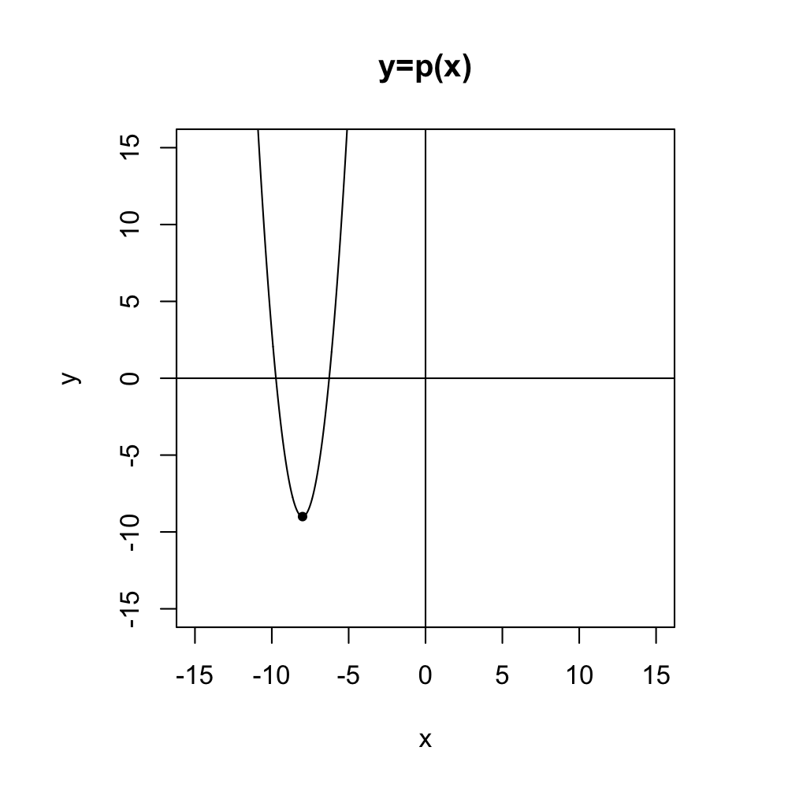

Quadratic polynomial $p$ is defined below in standard form.
$$p(x)~=~{2}x^{2}-{32}x+{119}$$

By [completing the square](https://en.wikipedia.org/wiki/Completing_the_square), you can rewrite the quadratic polynomial in vertex form:

$$p(x) = a(x-h)^2+k$$

where $(h,k)$ is the vertex of the parabola. Determine the coordinates of the vertex of quadratic polynomial $p$.

- $h=$
- $k=$

We are given $p(x)~=~{2}x^{2}-{32}x+{119}$. From the first two terms, factor out 2.

$$p(x)~=~2\left(x^{2}-{16}x\right)+{119}$$

Determine the constant needed to complete the square (of the expression inside parentheses) by dividing the linear coefficient by 2 and then squaring the result. $\left(\frac{-16}{2}\right)^2 ~=~ \left(-8\right)^2 ~=~ 64$. Add and subtract this amount inside the parentheses.

$$p(x)~=~2\left(x^{2}-{16}x+{64}-{64}\right)+{119}$$

Notice the first three terms inside the parentheses are a perfect square. Rewrite them in factored form.

$$p(x)~=~2\left(\left(x-{8}\right)^2-64\right)+{119}$$

Distribute the 2.

$$p(x)~=~2\left(x-{8}\right)^2-128+{119}$$

Combine the constants.

$$p(x)~=~2\left(x-{8}\right)^2
-{9}$$

And so:

$$h = 8$$
$$k = -9$$

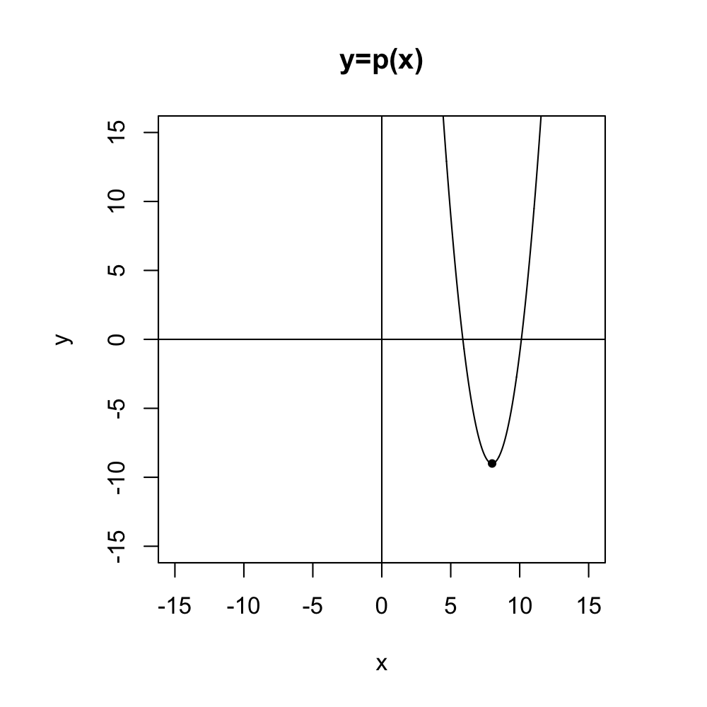

Quadratic polynomial $p$ is defined below in standard form.
$$p(x)~=~{5}x^{2}+{70}x+{240}$$

By [completing the square](https://en.wikipedia.org/wiki/Completing_the_square), you can rewrite the quadratic polynomial in vertex form:

$$p(x) = a(x-h)^2+k$$

where $(h,k)$ is the vertex of the parabola. Determine the coordinates of the vertex of quadratic polynomial $p$.

- $h=$
- $k=$

We are given $p(x)~=~{5}x^{2}+{70}x+{240}$. From the first two terms, factor out 5.

$$p(x)~=~5\left(x^{2}+{14}x\right)+{240}$$

Determine the constant needed to complete the square (of the expression inside parentheses) by dividing the linear coefficient by 2 and then squaring the result. $\left(\frac{14}{2}\right)^2 ~=~ \left(7\right)^2 ~=~ 49$. Add and subtract this amount inside the parentheses.

$$p(x)~=~5\left(x^{2}+{14}x+{49}-{49}\right)+{240}$$

Notice the first three terms inside the parentheses are a perfect square. Rewrite them in factored form.

$$p(x)~=~5\left(\left(x+{7}\right)^2-49\right)+{240}$$

Distribute the 5.

$$p(x)~=~5\left(x+{7}\right)^2-245+{240}$$

Combine the constants.

$$p(x)~=~5\left(x+{7}\right)^2
-{5}$$

And so:

$$h = -7$$
$$k = -5$$

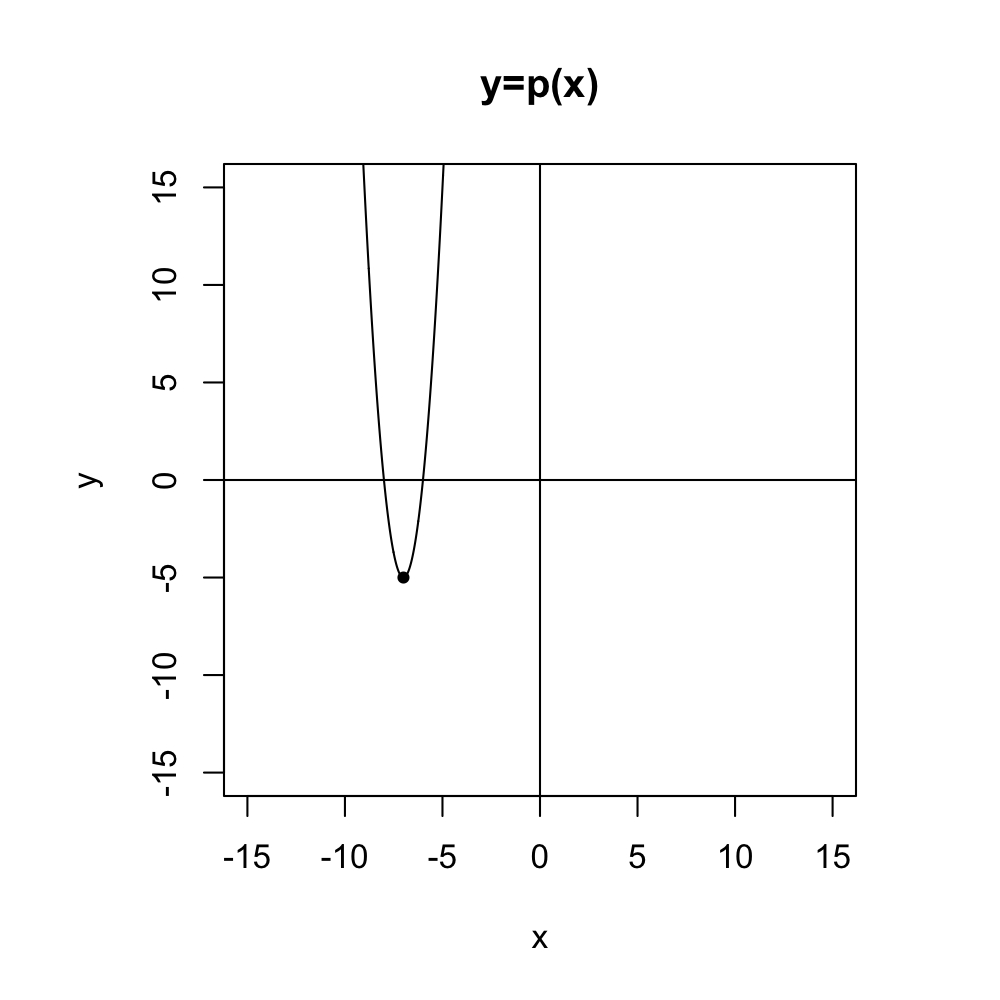

Quadratic polynomial $p$ is defined below in standard form.
$$p(x)~=~{4}x^{2}+{32}x+{55}$$

By [completing the square](https://en.wikipedia.org/wiki/Completing_the_square), you can rewrite the quadratic polynomial in vertex form:

$$p(x) = a(x-h)^2+k$$

where $(h,k)$ is the vertex of the parabola. Determine the coordinates of the vertex of quadratic polynomial $p$.

- $h=$
- $k=$

We are given $p(x)~=~{4}x^{2}+{32}x+{55}$. From the first two terms, factor out 4.

$$p(x)~=~4\left(x^{2}+{8}x\right)+{55}$$

Determine the constant needed to complete the square (of the expression inside parentheses) by dividing the linear coefficient by 2 and then squaring the result. $\left(\frac{8}{2}\right)^2 ~=~ \left(4\right)^2 ~=~ 16$. Add and subtract this amount inside the parentheses.

$$p(x)~=~4\left(x^{2}+{8}x+{16}-{16}\right)+{55}$$

Notice the first three terms inside the parentheses are a perfect square. Rewrite them in factored form.

$$p(x)~=~4\left(\left(x+{4}\right)^2-16\right)+{55}$$

Distribute the 4.

$$p(x)~=~4\left(x+{4}\right)^2-64+{55}$$

Combine the constants.

$$p(x)~=~4\left(x+{4}\right)^2
-{9}$$

And so:

$$h = -4$$
$$k = -9$$

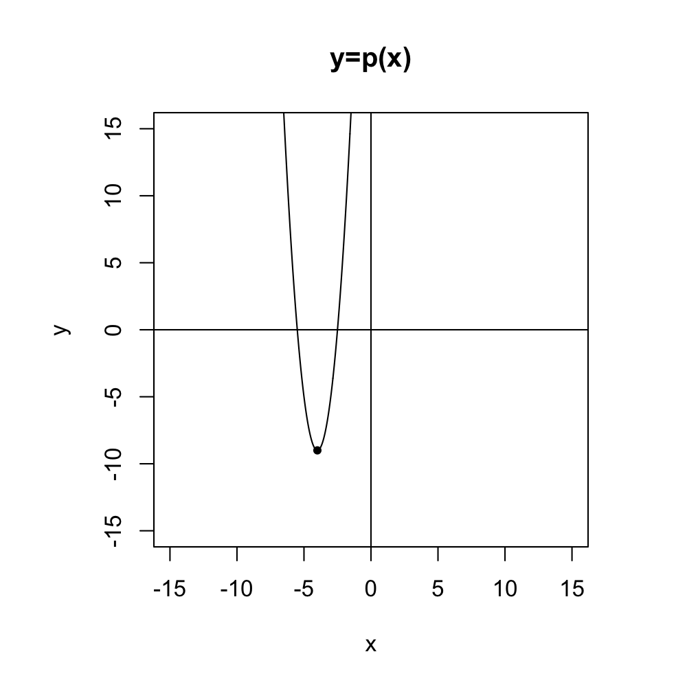

Quadratic polynomial $p$ is defined below in standard form.
$$p(x)~=~{3}x^{2}+{42}x+{143}$$

By [completing the square](https://en.wikipedia.org/wiki/Completing_the_square), you can rewrite the quadratic polynomial in vertex form:

$$p(x) = a(x-h)^2+k$$

where $(h,k)$ is the vertex of the parabola. Determine the coordinates of the vertex of quadratic polynomial $p$.

- $h=$
- $k=$

We are given $p(x)~=~{3}x^{2}+{42}x+{143}$. From the first two terms, factor out 3.

$$p(x)~=~3\left(x^{2}+{14}x\right)+{143}$$

Determine the constant needed to complete the square (of the expression inside parentheses) by dividing the linear coefficient by 2 and then squaring the result. $\left(\frac{14}{2}\right)^2 ~=~ \left(7\right)^2 ~=~ 49$. Add and subtract this amount inside the parentheses.

$$p(x)~=~3\left(x^{2}+{14}x+{49}-{49}\right)+{143}$$

Notice the first three terms inside the parentheses are a perfect square. Rewrite them in factored form.

$$p(x)~=~3\left(\left(x+{7}\right)^2-49\right)+{143}$$

Distribute the 3.

$$p(x)~=~3\left(x+{7}\right)^2-147+{143}$$

Combine the constants.

$$p(x)~=~3\left(x+{7}\right)^2
-{4}$$

And so:

$$h = -7$$
$$k = -4$$

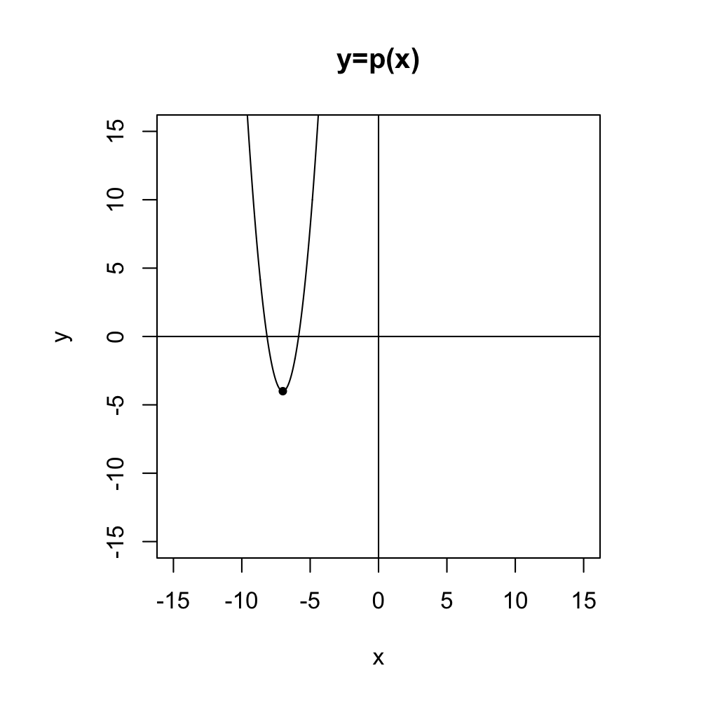

Quadratic polynomial $p$ is defined below in standard form.
$$p(x)~=~{4}x^{2}+{32}x+{57}$$

By [completing the square](https://en.wikipedia.org/wiki/Completing_the_square), you can rewrite the quadratic polynomial in vertex form:

$$p(x) = a(x-h)^2+k$$

where $(h,k)$ is the vertex of the parabola. Determine the coordinates of the vertex of quadratic polynomial $p$.

- $h=$
- $k=$

We are given $p(x)~=~{4}x^{2}+{32}x+{57}$. From the first two terms, factor out 4.

$$p(x)~=~4\left(x^{2}+{8}x\right)+{57}$$

Determine the constant needed to complete the square (of the expression inside parentheses) by dividing the linear coefficient by 2 and then squaring the result. $\left(\frac{8}{2}\right)^2 ~=~ \left(4\right)^2 ~=~ 16$. Add and subtract this amount inside the parentheses.

$$p(x)~=~4\left(x^{2}+{8}x+{16}-{16}\right)+{57}$$

Notice the first three terms inside the parentheses are a perfect square. Rewrite them in factored form.

$$p(x)~=~4\left(\left(x+{4}\right)^2-16\right)+{57}$$

Distribute the 4.

$$p(x)~=~4\left(x+{4}\right)^2-64+{57}$$

Combine the constants.

$$p(x)~=~4\left(x+{4}\right)^2
-{7}$$

And so:

$$h = -4$$
$$k = -7$$

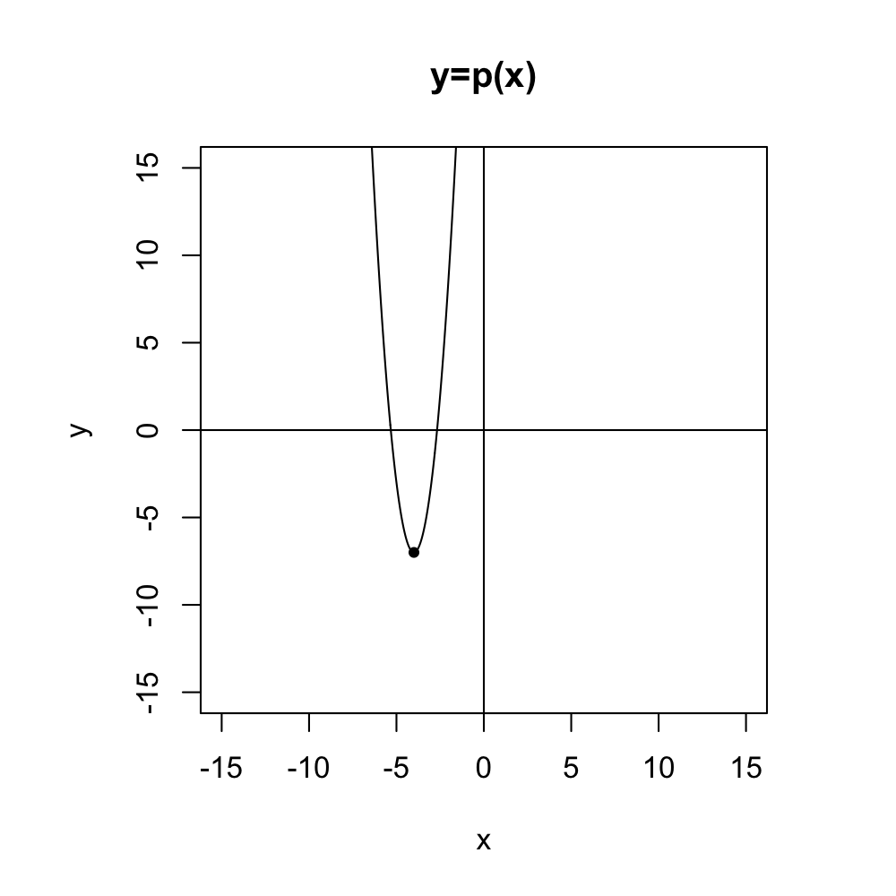

Quadratic polynomial $p$ is defined below in standard form.
$$p(x)~=~{3}x^{2}-{18}x+{31}$$

By [completing the square](https://en.wikipedia.org/wiki/Completing_the_square), you can rewrite the quadratic polynomial in vertex form:

$$p(x) = a(x-h)^2+k$$

where $(h,k)$ is the vertex of the parabola. Determine the coordinates of the vertex of quadratic polynomial $p$.

- $h=$
- $k=$

We are given $p(x)~=~{3}x^{2}-{18}x+{31}$. From the first two terms, factor out 3.

$$p(x)~=~3\left(x^{2}-{6}x\right)+{31}$$

Determine the constant needed to complete the square (of the expression inside parentheses) by dividing the linear coefficient by 2 and then squaring the result. $\left(\frac{-6}{2}\right)^2 ~=~ \left(-3\right)^2 ~=~ 9$. Add and subtract this amount inside the parentheses.

$$p(x)~=~3\left(x^{2}-{6}x+{9}-{9}\right)+{31}$$

Notice the first three terms inside the parentheses are a perfect square. Rewrite them in factored form.

$$p(x)~=~3\left(\left(x-{3}\right)^2-9\right)+{31}$$

Distribute the 3.

$$p(x)~=~3\left(x-{3}\right)^2-27+{31}$$

Combine the constants.

$$p(x)~=~3\left(x-{3}\right)^2
+{4}$$

And so:

$$h = 3$$
$$k = 4$$

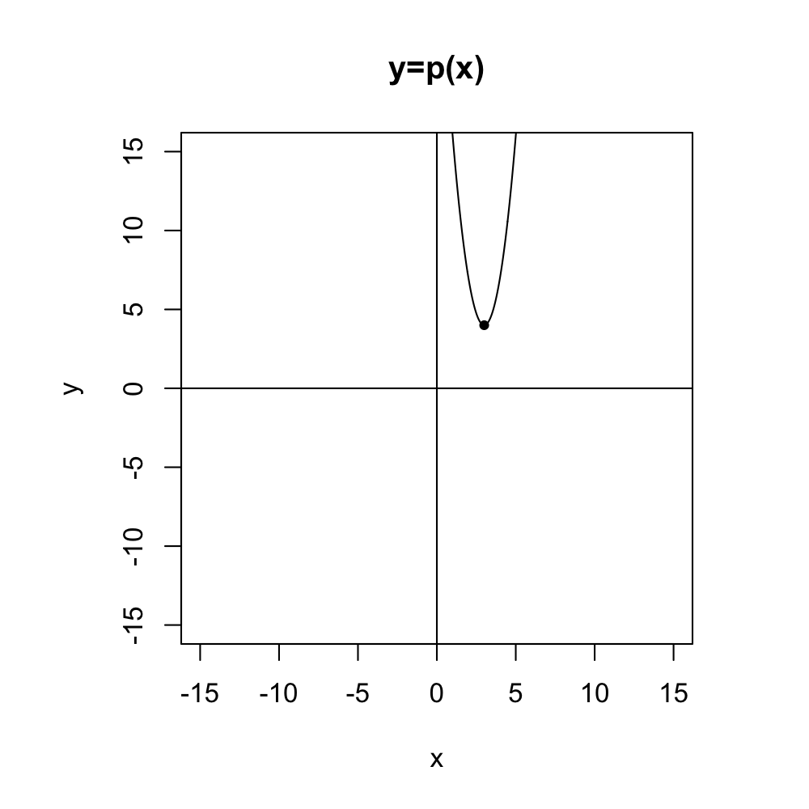

Quadratic polynomial $p$ is defined below in standard form.
$$p(x)~=~{4}x^{2}-{40}x+{92}$$

By [completing the square](https://en.wikipedia.org/wiki/Completing_the_square), you can rewrite the quadratic polynomial in vertex form:

$$p(x) = a(x-h)^2+k$$

where $(h,k)$ is the vertex of the parabola. Determine the coordinates of the vertex of quadratic polynomial $p$.

- $h=$
- $k=$

We are given $p(x)~=~{4}x^{2}-{40}x+{92}$. From the first two terms, factor out 4.

$$p(x)~=~4\left(x^{2}-{10}x\right)+{92}$$

Determine the constant needed to complete the square (of the expression inside parentheses) by dividing the linear coefficient by 2 and then squaring the result. $\left(\frac{-10}{2}\right)^2 ~=~ \left(-5\right)^2 ~=~ 25$. Add and subtract this amount inside the parentheses.

$$p(x)~=~4\left(x^{2}-{10}x+{25}-{25}\right)+{92}$$

Notice the first three terms inside the parentheses are a perfect square. Rewrite them in factored form.

$$p(x)~=~4\left(\left(x-{5}\right)^2-25\right)+{92}$$

Distribute the 4.

$$p(x)~=~4\left(x-{5}\right)^2-100+{92}$$

Combine the constants.

$$p(x)~=~4\left(x-{5}\right)^2
-{8}$$

And so:

$$h = 5$$
$$k = -8$$

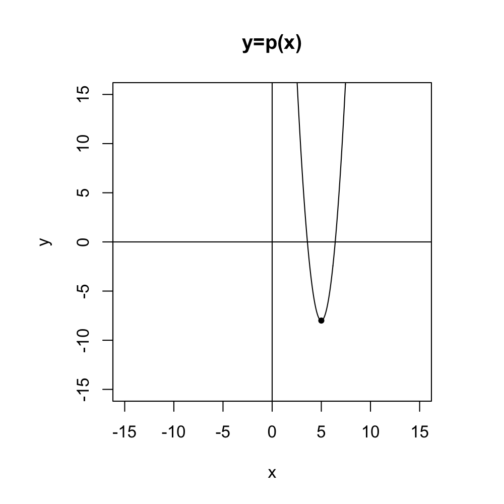

Quadratic polynomial $p$ is defined below in standard form.
$$p(x)~=~{3}x^{2}+{18}x+{32}$$

By [completing the square](https://en.wikipedia.org/wiki/Completing_the_square), you can rewrite the quadratic polynomial in vertex form:

$$p(x) = a(x-h)^2+k$$

where $(h,k)$ is the vertex of the parabola. Determine the coordinates of the vertex of quadratic polynomial $p$.

- $h=$
- $k=$

We are given $p(x)~=~{3}x^{2}+{18}x+{32}$. From the first two terms, factor out 3.

$$p(x)~=~3\left(x^{2}+{6}x\right)+{32}$$

Determine the constant needed to complete the square (of the expression inside parentheses) by dividing the linear coefficient by 2 and then squaring the result. $\left(\frac{6}{2}\right)^2 ~=~ \left(3\right)^2 ~=~ 9$. Add and subtract this amount inside the parentheses.

$$p(x)~=~3\left(x^{2}+{6}x+{9}-{9}\right)+{32}$$

Notice the first three terms inside the parentheses are a perfect square. Rewrite them in factored form.

$$p(x)~=~3\left(\left(x+{3}\right)^2-9\right)+{32}$$

Distribute the 3.

$$p(x)~=~3\left(x+{3}\right)^2-27+{32}$$

Combine the constants.

$$p(x)~=~3\left(x+{3}\right)^2
+{5}$$

And so:

$$h = -3$$
$$k = 5$$

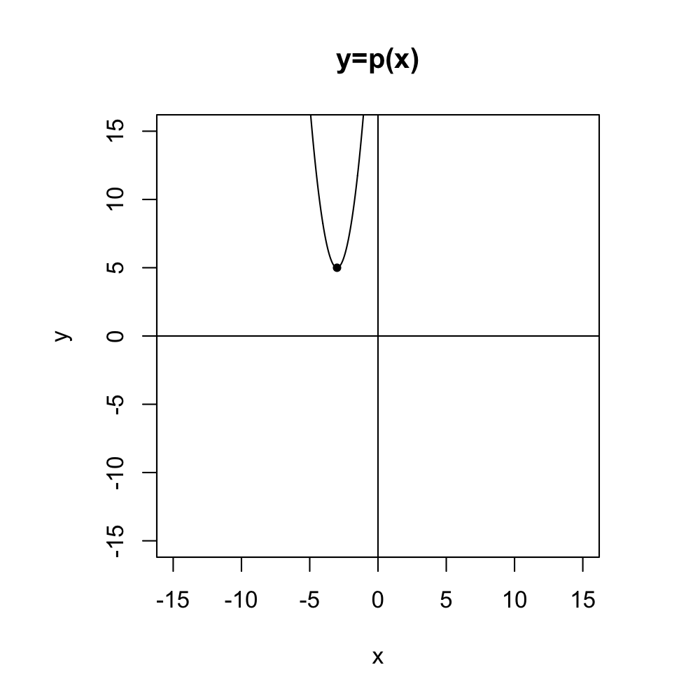

Quadratic polynomial $p$ is defined below in standard form.
$$p(x)~=~{4}x^{2}-{48}x+{148}$$

By [completing the square](https://en.wikipedia.org/wiki/Completing_the_square), you can rewrite the quadratic polynomial in vertex form:

$$p(x) = a(x-h)^2+k$$

where $(h,k)$ is the vertex of the parabola. Determine the coordinates of the vertex of quadratic polynomial $p$.

- $h=$
- $k=$

We are given $p(x)~=~{4}x^{2}-{48}x+{148}$. From the first two terms, factor out 4.

$$p(x)~=~4\left(x^{2}-{12}x\right)+{148}$$

Determine the constant needed to complete the square (of the expression inside parentheses) by dividing the linear coefficient by 2 and then squaring the result. $\left(\frac{-12}{2}\right)^2 ~=~ \left(-6\right)^2 ~=~ 36$. Add and subtract this amount inside the parentheses.

$$p(x)~=~4\left(x^{2}-{12}x+{36}-{36}\right)+{148}$$

Notice the first three terms inside the parentheses are a perfect square. Rewrite them in factored form.

$$p(x)~=~4\left(\left(x-{6}\right)^2-36\right)+{148}$$

Distribute the 4.

$$p(x)~=~4\left(x-{6}\right)^2-144+{148}$$

Combine the constants.

$$p(x)~=~4\left(x-{6}\right)^2
+{4}$$

And so:

$$h = 6$$
$$k = 4$$

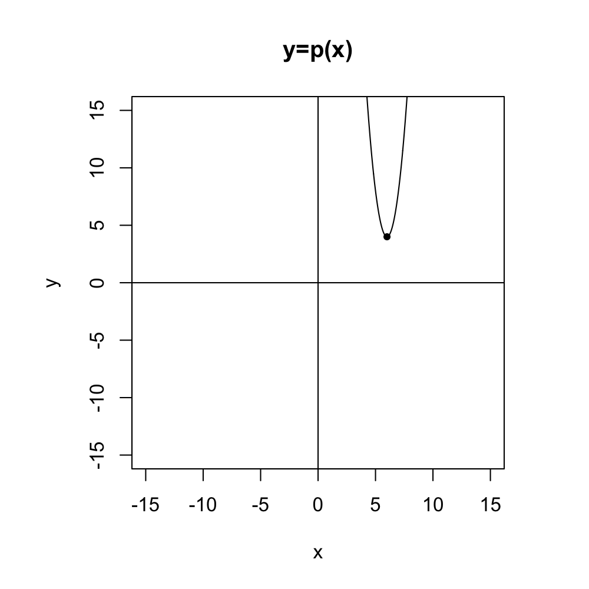

Quadratic polynomial $p$ is defined below in standard form.
$$p(x)~=~{4}x^{2}+{16}x+{20}$$

By [completing the square](https://en.wikipedia.org/wiki/Completing_the_square), you can rewrite the quadratic polynomial in vertex form:

$$p(x) = a(x-h)^2+k$$

where $(h,k)$ is the vertex of the parabola. Determine the coordinates of the vertex of quadratic polynomial $p$.

- $h=$
- $k=$

We are given $p(x)~=~{4}x^{2}+{16}x+{20}$. From the first two terms, factor out 4.

$$p(x)~=~4\left(x^{2}+{4}x\right)+{20}$$

Determine the constant needed to complete the square (of the expression inside parentheses) by dividing the linear coefficient by 2 and then squaring the result. $\left(\frac{4}{2}\right)^2 ~=~ \left(2\right)^2 ~=~ 4$. Add and subtract this amount inside the parentheses.

$$p(x)~=~4\left(x^{2}+{4}x+{4}-{4}\right)+{20}$$

Notice the first three terms inside the parentheses are a perfect square. Rewrite them in factored form.

$$p(x)~=~4\left(\left(x+{2}\right)^2-4\right)+{20}$$

Distribute the 4.

$$p(x)~=~4\left(x+{2}\right)^2-16+{20}$$

Combine the constants.

$$p(x)~=~4\left(x+{2}\right)^2
+{4}$$

And so:

$$h = -2$$
$$k = 4$$

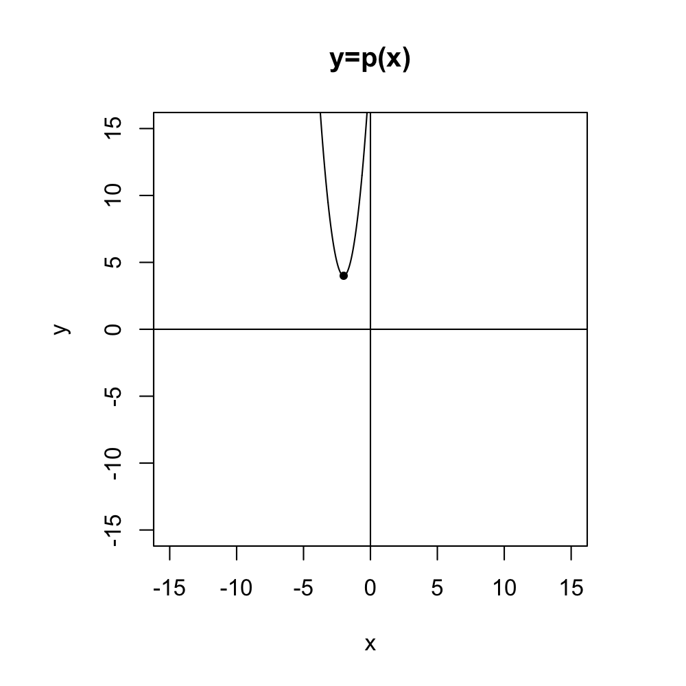

Quadratic polynomial $p$ is defined below in standard form.
$$p(x)~=~{4}x^{2}+{72}x+{326}$$

By [completing the square](https://en.wikipedia.org/wiki/Completing_the_square), you can rewrite the quadratic polynomial in vertex form:

$$p(x) = a(x-h)^2+k$$

where $(h,k)$ is the vertex of the parabola. Determine the coordinates of the vertex of quadratic polynomial $p$.

- $h=$
- $k=$

We are given $p(x)~=~{4}x^{2}+{72}x+{326}$. From the first two terms, factor out 4.

$$p(x)~=~4\left(x^{2}+{18}x\right)+{326}$$

Determine the constant needed to complete the square (of the expression inside parentheses) by dividing the linear coefficient by 2 and then squaring the result. $\left(\frac{18}{2}\right)^2 ~=~ \left(9\right)^2 ~=~ 81$. Add and subtract this amount inside the parentheses.

$$p(x)~=~4\left(x^{2}+{18}x+{81}-{81}\right)+{326}$$

Notice the first three terms inside the parentheses are a perfect square. Rewrite them in factored form.

$$p(x)~=~4\left(\left(x+{9}\right)^2-81\right)+{326}$$

Distribute the 4.

$$p(x)~=~4\left(x+{9}\right)^2-324+{326}$$

Combine the constants.

$$p(x)~=~4\left(x+{9}\right)^2
+{2}$$

And so:

$$h = -9$$
$$k = 2$$

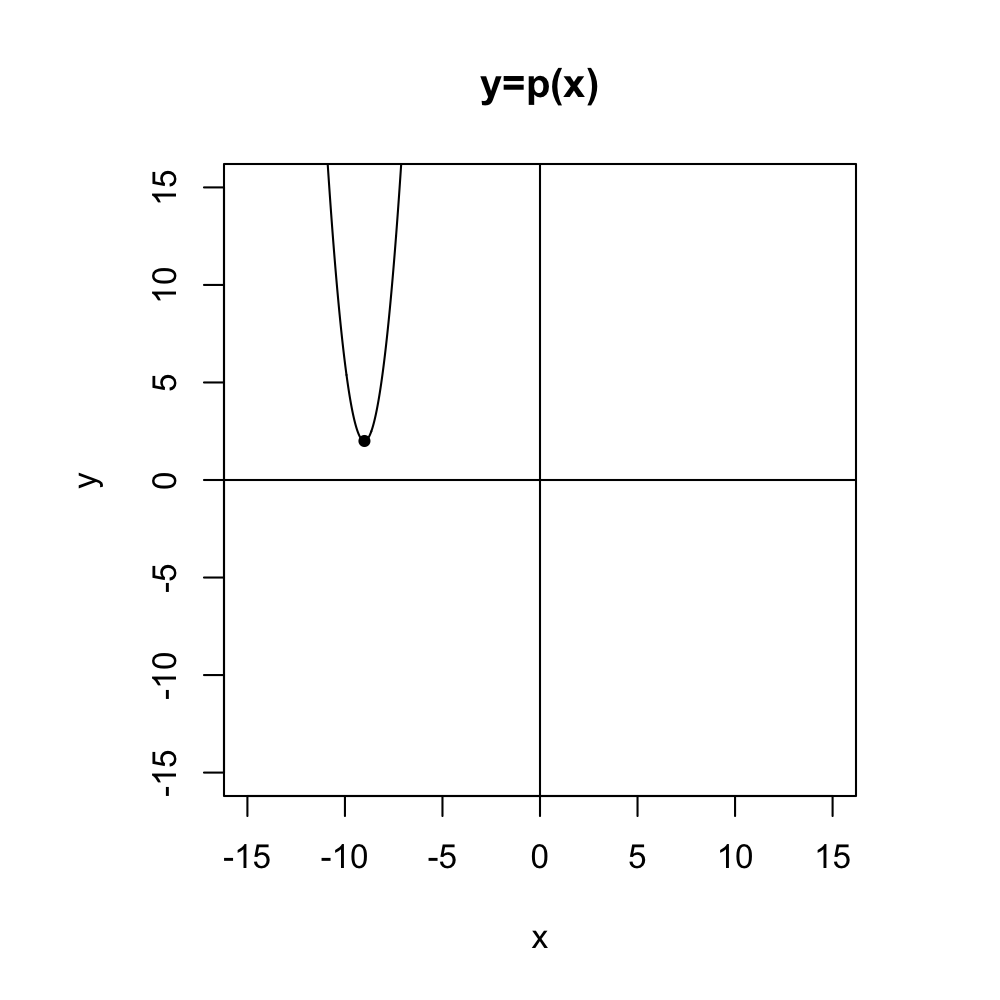

Quadratic polynomial $p$ is defined below in standard form.
$$p(x)~=~{3}x^{2}-{24}x+{57}$$

By [completing the square](https://en.wikipedia.org/wiki/Completing_the_square), you can rewrite the quadratic polynomial in vertex form:

$$p(x) = a(x-h)^2+k$$

where $(h,k)$ is the vertex of the parabola. Determine the coordinates of the vertex of quadratic polynomial $p$.

- $h=$
- $k=$

We are given $p(x)~=~{3}x^{2}-{24}x+{57}$. From the first two terms, factor out 3.

$$p(x)~=~3\left(x^{2}-{8}x\right)+{57}$$

Determine the constant needed to complete the square (of the expression inside parentheses) by dividing the linear coefficient by 2 and then squaring the result. $\left(\frac{-8}{2}\right)^2 ~=~ \left(-4\right)^2 ~=~ 16$. Add and subtract this amount inside the parentheses.

$$p(x)~=~3\left(x^{2}-{8}x+{16}-{16}\right)+{57}$$

Notice the first three terms inside the parentheses are a perfect square. Rewrite them in factored form.

$$p(x)~=~3\left(\left(x-{4}\right)^2-16\right)+{57}$$

Distribute the 3.

$$p(x)~=~3\left(x-{4}\right)^2-48+{57}$$

Combine the constants.

$$p(x)~=~3\left(x-{4}\right)^2
+{9}$$

And so:

$$h = 4$$
$$k = 9$$

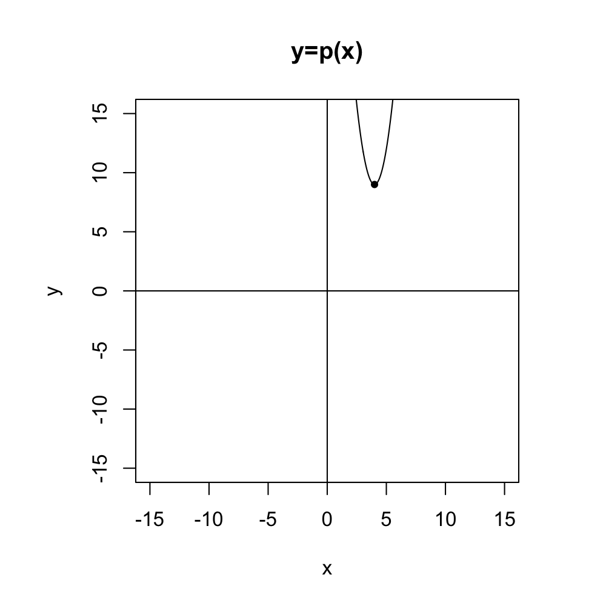

Quadratic polynomial $p$ is defined below in standard form.
$$p(x)~=~{3}x^{2}+{36}x+{115}$$

By [completing the square](https://en.wikipedia.org/wiki/Completing_the_square), you can rewrite the quadratic polynomial in vertex form:

$$p(x) = a(x-h)^2+k$$

where $(h,k)$ is the vertex of the parabola. Determine the coordinates of the vertex of quadratic polynomial $p$.

- $h=$
- $k=$

We are given $p(x)~=~{3}x^{2}+{36}x+{115}$. From the first two terms, factor out 3.

$$p(x)~=~3\left(x^{2}+{12}x\right)+{115}$$

Determine the constant needed to complete the square (of the expression inside parentheses) by dividing the linear coefficient by 2 and then squaring the result. $\left(\frac{12}{2}\right)^2 ~=~ \left(6\right)^2 ~=~ 36$. Add and subtract this amount inside the parentheses.

$$p(x)~=~3\left(x^{2}+{12}x+{36}-{36}\right)+{115}$$

Notice the first three terms inside the parentheses are a perfect square. Rewrite them in factored form.

$$p(x)~=~3\left(\left(x+{6}\right)^2-36\right)+{115}$$

Distribute the 3.

$$p(x)~=~3\left(x+{6}\right)^2-108+{115}$$

Combine the constants.

$$p(x)~=~3\left(x+{6}\right)^2
+{7}$$

And so:

$$h = -6$$
$$k = 7$$

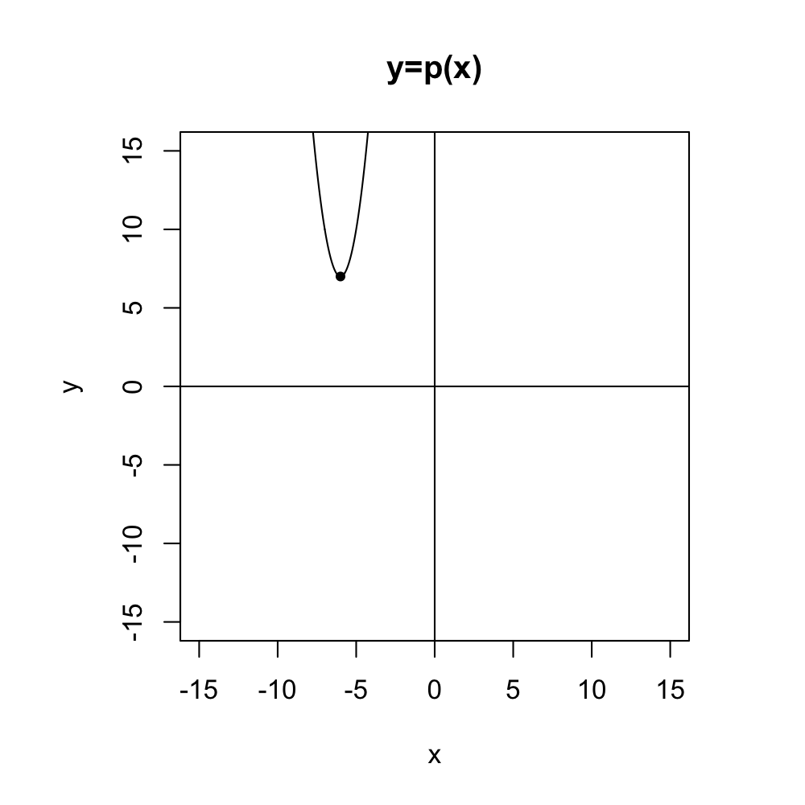

Quadratic polynomial $p$ is defined below in standard form.
$$p(x)~=~{3}x^{2}+{42}x+{144}$$

By [completing the square](https://en.wikipedia.org/wiki/Completing_the_square), you can rewrite the quadratic polynomial in vertex form:

$$p(x) = a(x-h)^2+k$$

where $(h,k)$ is the vertex of the parabola. Determine the coordinates of the vertex of quadratic polynomial $p$.

- $h=$
- $k=$

We are given $p(x)~=~{3}x^{2}+{42}x+{144}$. From the first two terms, factor out 3.

$$p(x)~=~3\left(x^{2}+{14}x\right)+{144}$$

Determine the constant needed to complete the square (of the expression inside parentheses) by dividing the linear coefficient by 2 and then squaring the result. $\left(\frac{14}{2}\right)^2 ~=~ \left(7\right)^2 ~=~ 49$. Add and subtract this amount inside the parentheses.

$$p(x)~=~3\left(x^{2}+{14}x+{49}-{49}\right)+{144}$$

Notice the first three terms inside the parentheses are a perfect square. Rewrite them in factored form.

$$p(x)~=~3\left(\left(x+{7}\right)^2-49\right)+{144}$$

Distribute the 3.

$$p(x)~=~3\left(x+{7}\right)^2-147+{144}$$

Combine the constants.

$$p(x)~=~3\left(x+{7}\right)^2
-{3}$$

And so:

$$h = -7$$
$$k = -3$$

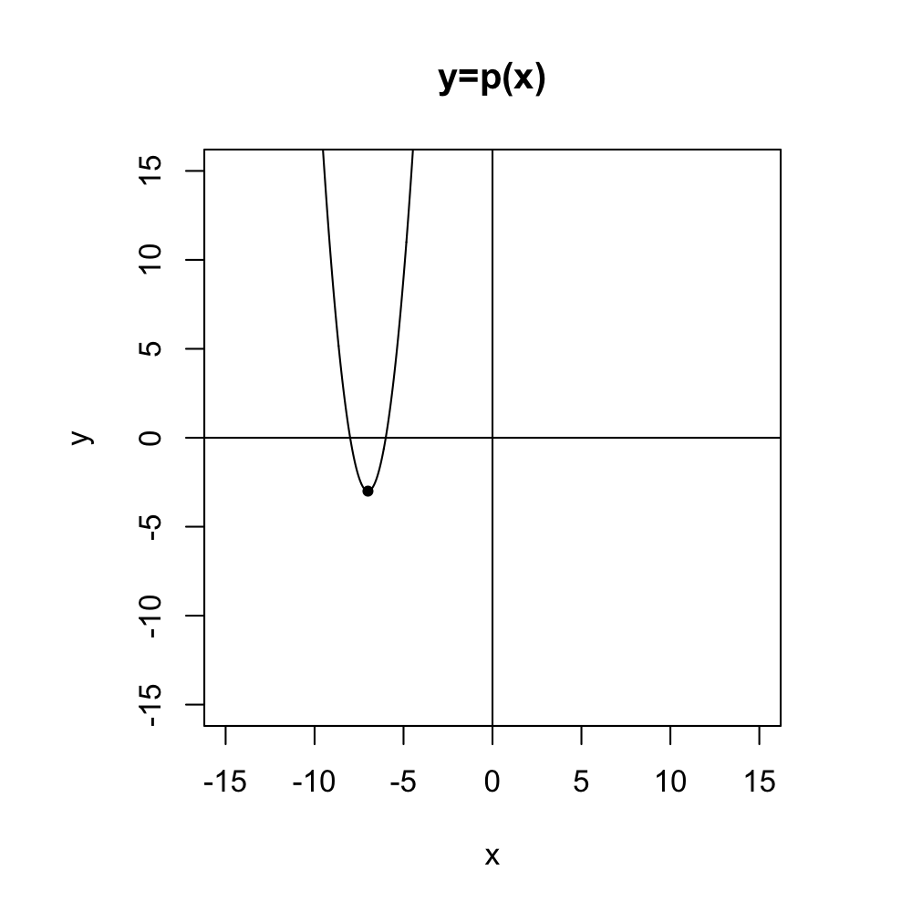

Quadratic polynomial $p$ is defined below in standard form.
$$p(x)~=~{2}x^{2}-{24}x+{65}$$

By [completing the square](https://en.wikipedia.org/wiki/Completing_the_square), you can rewrite the quadratic polynomial in vertex form:

$$p(x) = a(x-h)^2+k$$

where $(h,k)$ is the vertex of the parabola. Determine the coordinates of the vertex of quadratic polynomial $p$.

- $h=$
- $k=$

We are given $p(x)~=~{2}x^{2}-{24}x+{65}$. From the first two terms, factor out 2.

$$p(x)~=~2\left(x^{2}-{12}x\right)+{65}$$

Determine the constant needed to complete the square (of the expression inside parentheses) by dividing the linear coefficient by 2 and then squaring the result. $\left(\frac{-12}{2}\right)^2 ~=~ \left(-6\right)^2 ~=~ 36$. Add and subtract this amount inside the parentheses.

$$p(x)~=~2\left(x^{2}-{12}x+{36}-{36}\right)+{65}$$

Notice the first three terms inside the parentheses are a perfect square. Rewrite them in factored form.

$$p(x)~=~2\left(\left(x-{6}\right)^2-36\right)+{65}$$

Distribute the 2.

$$p(x)~=~2\left(x-{6}\right)^2-72+{65}$$

Combine the constants.

$$p(x)~=~2\left(x-{6}\right)^2
-{7}$$

And so:

$$h = 6$$
$$k = -7$$

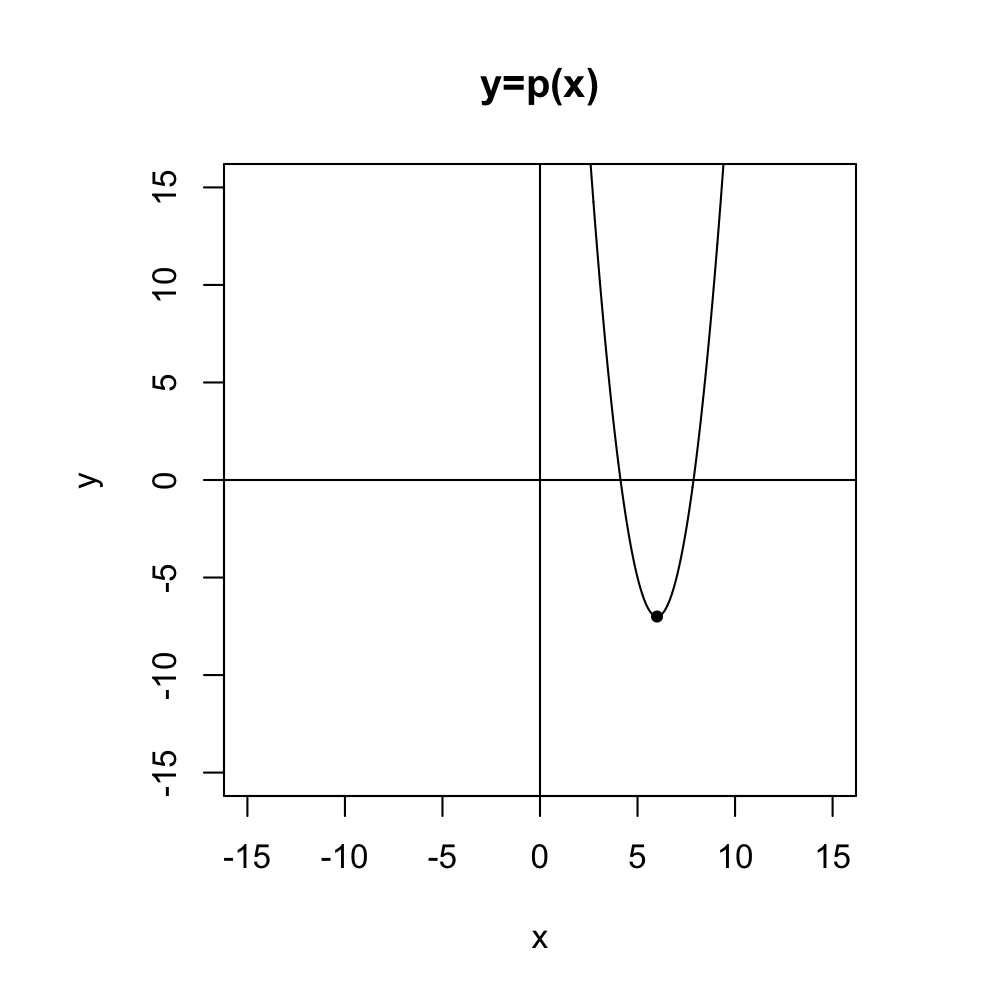

Quadratic polynomial $p$ is defined below in standard form.
$$p(x)~=~{4}x^{2}-{40}x+{98}$$

By [completing the square](https://en.wikipedia.org/wiki/Completing_the_square), you can rewrite the quadratic polynomial in vertex form:

$$p(x) = a(x-h)^2+k$$

where $(h,k)$ is the vertex of the parabola. Determine the coordinates of the vertex of quadratic polynomial $p$.

- $h=$
- $k=$

We are given $p(x)~=~{4}x^{2}-{40}x+{98}$. From the first two terms, factor out 4.

$$p(x)~=~4\left(x^{2}-{10}x\right)+{98}$$

Determine the constant needed to complete the square (of the expression inside parentheses) by dividing the linear coefficient by 2 and then squaring the result. $\left(\frac{-10}{2}\right)^2 ~=~ \left(-5\right)^2 ~=~ 25$. Add and subtract this amount inside the parentheses.

$$p(x)~=~4\left(x^{2}-{10}x+{25}-{25}\right)+{98}$$

Notice the first three terms inside the parentheses are a perfect square. Rewrite them in factored form.

$$p(x)~=~4\left(\left(x-{5}\right)^2-25\right)+{98}$$

Distribute the 4.

$$p(x)~=~4\left(x-{5}\right)^2-100+{98}$$

Combine the constants.

$$p(x)~=~4\left(x-{5}\right)^2
-{2}$$

And so:

$$h = 5$$
$$k = -2$$

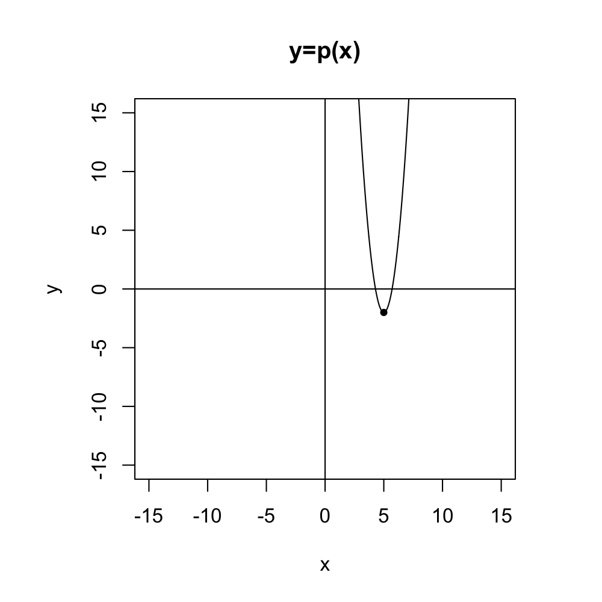

Quadratic polynomial $p$ is defined below in standard form.
$$p(x)~=~{3}x^{2}+{36}x+{103}$$

By [completing the square](https://en.wikipedia.org/wiki/Completing_the_square), you can rewrite the quadratic polynomial in vertex form:

$$p(x) = a(x-h)^2+k$$

where $(h,k)$ is the vertex of the parabola. Determine the coordinates of the vertex of quadratic polynomial $p$.

- $h=$
- $k=$

We are given $p(x)~=~{3}x^{2}+{36}x+{103}$. From the first two terms, factor out 3.

$$p(x)~=~3\left(x^{2}+{12}x\right)+{103}$$

Determine the constant needed to complete the square (of the expression inside parentheses) by dividing the linear coefficient by 2 and then squaring the result. $\left(\frac{12}{2}\right)^2 ~=~ \left(6\right)^2 ~=~ 36$. Add and subtract this amount inside the parentheses.

$$p(x)~=~3\left(x^{2}+{12}x+{36}-{36}\right)+{103}$$

Notice the first three terms inside the parentheses are a perfect square. Rewrite them in factored form.

$$p(x)~=~3\left(\left(x+{6}\right)^2-36\right)+{103}$$

Distribute the 3.

$$p(x)~=~3\left(x+{6}\right)^2-108+{103}$$

Combine the constants.

$$p(x)~=~3\left(x+{6}\right)^2
-{5}$$

And so:

$$h = -6$$
$$k = -5$$

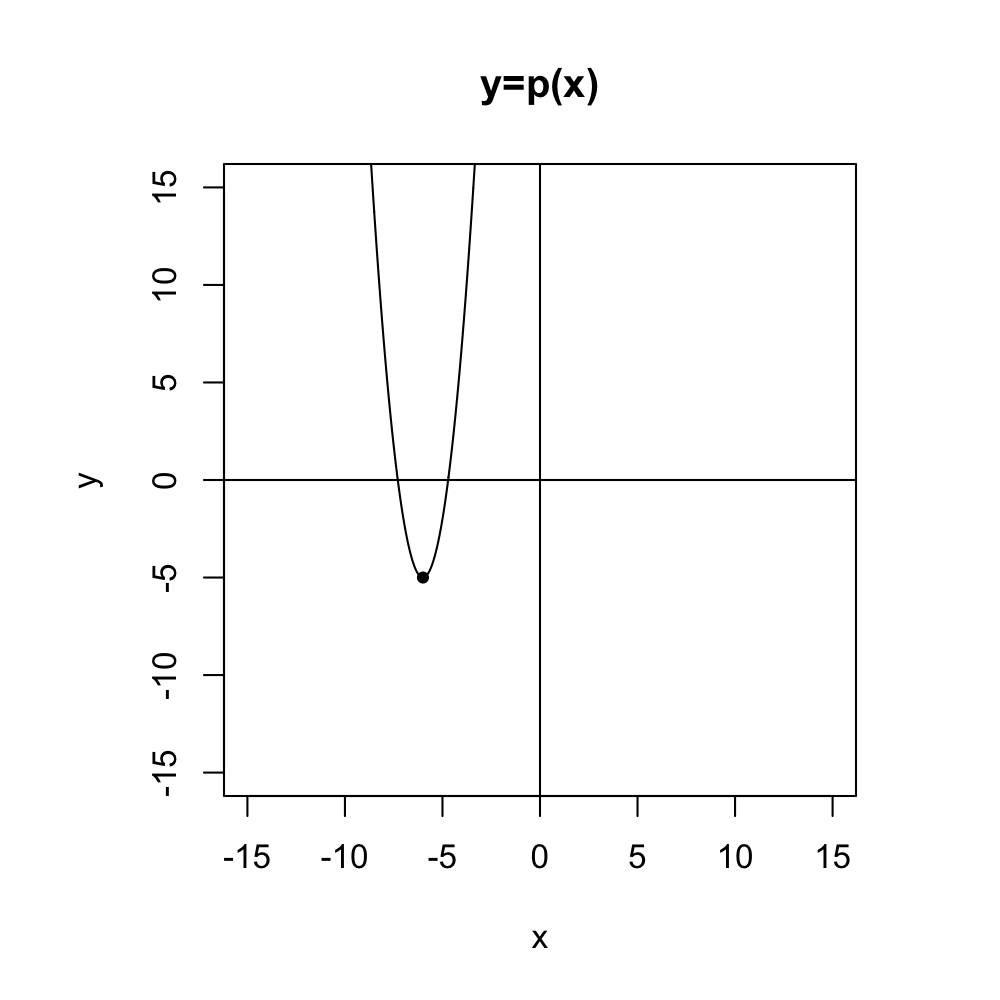

Quadratic polynomial $p$ is defined below in standard form.
$$p(x)~=~{3}x^{2}+{48}x+{201}$$

By [completing the square](https://en.wikipedia.org/wiki/Completing_the_square), you can rewrite the quadratic polynomial in vertex form:

$$p(x) = a(x-h)^2+k$$

where $(h,k)$ is the vertex of the parabola. Determine the coordinates of the vertex of quadratic polynomial $p$.

- $h=$
- $k=$

We are given $p(x)~=~{3}x^{2}+{48}x+{201}$. From the first two terms, factor out 3.

$$p(x)~=~3\left(x^{2}+{16}x\right)+{201}$$

Determine the constant needed to complete the square (of the expression inside parentheses) by dividing the linear coefficient by 2 and then squaring the result. $\left(\frac{16}{2}\right)^2 ~=~ \left(8\right)^2 ~=~ 64$. Add and subtract this amount inside the parentheses.

$$p(x)~=~3\left(x^{2}+{16}x+{64}-{64}\right)+{201}$$

Notice the first three terms inside the parentheses are a perfect square. Rewrite them in factored form.

$$p(x)~=~3\left(\left(x+{8}\right)^2-64\right)+{201}$$

Distribute the 3.

$$p(x)~=~3\left(x+{8}\right)^2-192+{201}$$

Combine the constants.

$$p(x)~=~3\left(x+{8}\right)^2
+{9}$$

And so:

$$h = -8$$
$$k = 9$$

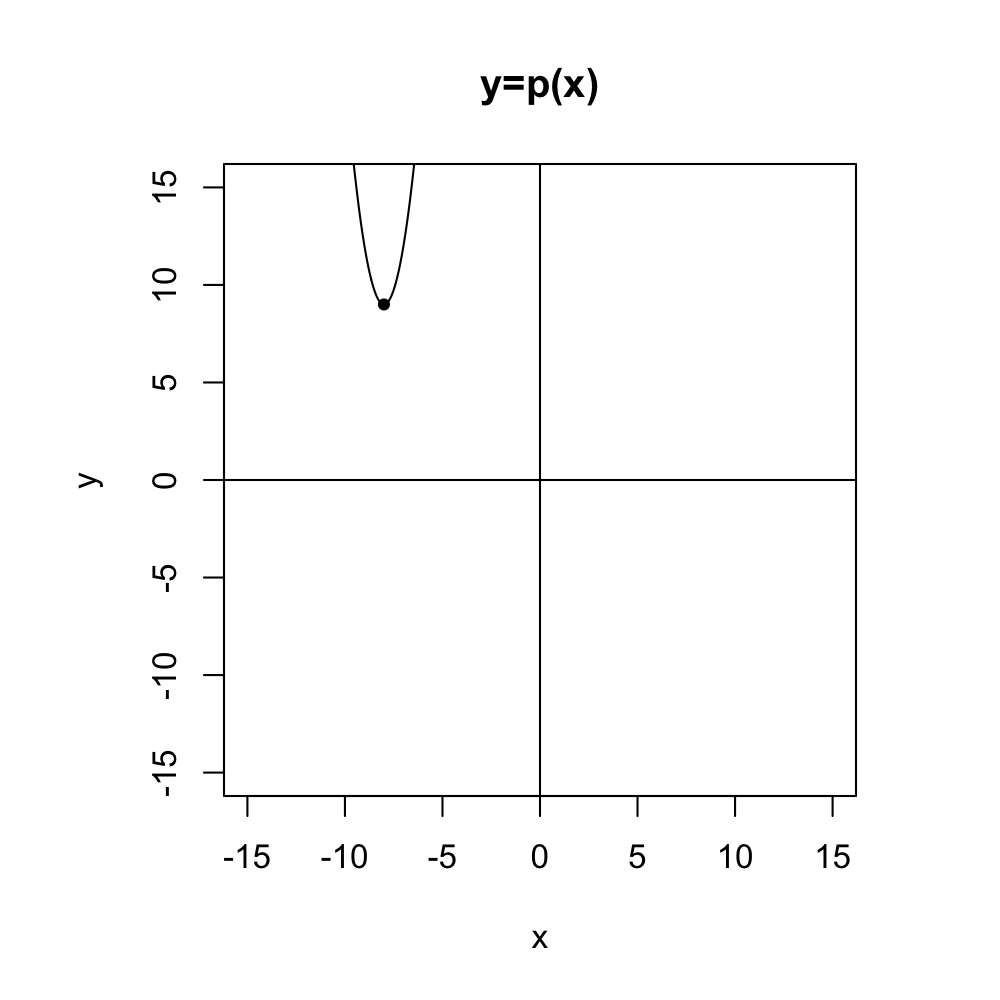

Quadratic polynomial $p$ is defined below in standard form.
$$p(x)~=~{5}x^{2}+{20}x+{24}$$

By [completing the square](https://en.wikipedia.org/wiki/Completing_the_square), you can rewrite the quadratic polynomial in vertex form:

$$p(x) = a(x-h)^2+k$$

where $(h,k)$ is the vertex of the parabola. Determine the coordinates of the vertex of quadratic polynomial $p$.

- $h=$
- $k=$

We are given $p(x)~=~{5}x^{2}+{20}x+{24}$. From the first two terms, factor out 5.

$$p(x)~=~5\left(x^{2}+{4}x\right)+{24}$$

Determine the constant needed to complete the square (of the expression inside parentheses) by dividing the linear coefficient by 2 and then squaring the result. $\left(\frac{4}{2}\right)^2 ~=~ \left(2\right)^2 ~=~ 4$. Add and subtract this amount inside the parentheses.

$$p(x)~=~5\left(x^{2}+{4}x+{4}-{4}\right)+{24}$$

Notice the first three terms inside the parentheses are a perfect square. Rewrite them in factored form.

$$p(x)~=~5\left(\left(x+{2}\right)^2-4\right)+{24}$$

Distribute the 5.

$$p(x)~=~5\left(x+{2}\right)^2-20+{24}$$

Combine the constants.

$$p(x)~=~5\left(x+{2}\right)^2
+{4}$$

And so:

$$h = -2$$
$$k = 4$$

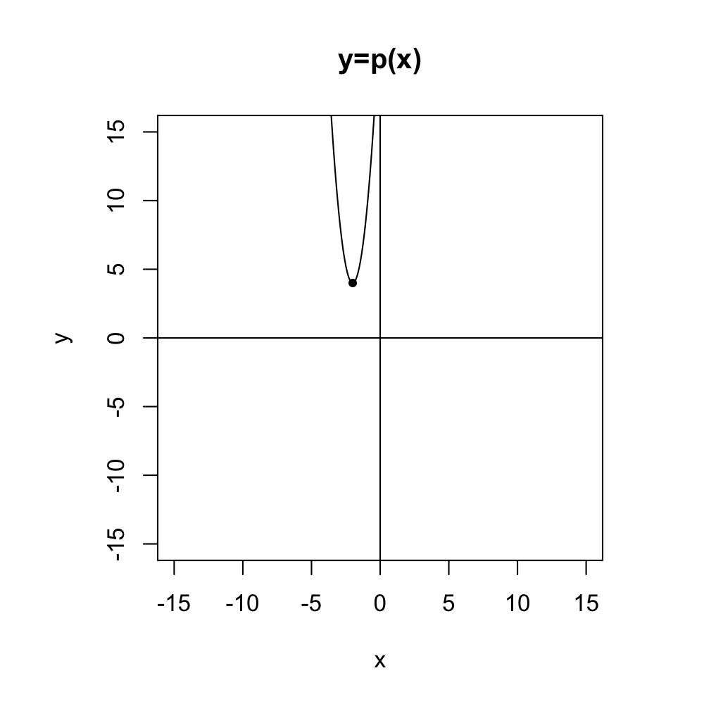